# **Analyzing the Effect of Digitalization on Economic Growth**

[figure not shown]

## Contributors

Advait Gupta <advait25@umd.edu>

Tushar Singh <tsingh98@umd.edu>

## **Introduction**

What drives economic growth in different countries? How do factors like internet penetration, digital infrastructure, and other macroeconomic indicators contribute to GDP? In a world where digital transformation is reshaping economies, some nations are reaping significant benefits, while others may take decades—or even over a century—to catch up with the GDP levels of top-performing countries.

This analysis delves into the **relationship between digitalization and GDP per capita**, measured in 2015 constant US dollars, and examines how key factors like **internet access, trade openness, government investment**, and **labor force participation** influence economic growth.

By analyzing international panel data from countries of varying income levels, we explore:

- **What contributes to GDP growth?**
- **How do internet access and digital development influence economies?**
- **Why do lower-income countries face longer timelines to match the GDP of wealthier nations?**

This study offers critical insights for policymakers and researchers seeking strategies to accelerate economic growth in a digitally driven world.

## **Why This Analysis Matters**

- **Digitalization as a Growth Driver**: Countries leveraging technological infrastructure, such as broadband access and internet penetration, experience accelerated economic development.
- **Cross-Country Comparisons**: By examining high, medium, and low-income nations, this analysis identifies disparities and commonalities in the role of digitalization.
- **Policy Implications**: Understanding these relationships helps craft effective strategies for fostering inclusive economic growth in a digital age.

## **Hypothesis and Intuition on Growth Factors for Low-Income Nations**

While high-income countries benefit from well-established digital infrastructures, low-income nations have a unique opportunity to boost their GDP growth by strategically focusing on specific digitalization factors. Here are some hypotheses and possible strategies based on the analysis:

1. **Hypothesis 1: Increasing Internet Penetration**  
   Low-income nations with low internet penetration could achieve significant GDP growth by improving access to the internet. Expanding internet access facilitates communication, access to markets, and the dissemination of knowledge. This, in turn, could boost productivity across various sectors, including agriculture, manufacturing, and services. Moreover, it enables better access to education and healthcare, leading to long-term improvements in human capital.

   **Year to Focus**: A low-income country could prioritize increasing internet penetration over the next 5-10 years to foster rapid growth.
2. **Hypothesis 2: Mobile Cellular Subscriptions as an Immediate Growth Lever**  
   In low-income countries, mobile phones often serve as a primary means of communication and access to information. By increasing mobile cellular subscriptions, countries can unlock immediate growth opportunities, especially in sectors such as e-commerce, mobile banking, and mobile health. Mobile technologies are also key to connecting rural areas with urban markets, improving access to services, and fostering entrepreneurial activity.

   **Year to Focus**: Immediate focus could be placed on increasing mobile cellular subscriptions in the next 3-5 years, particularly in rural and underserved areas.
3. **Hypothesis 3: Enhancing Broadband Access for Long-Term Growth**  
   While broadband access may not have the immediate impact of mobile technology, it plays a critical role in the long-term development of industries like education, healthcare, and digital innovation. Low-income countries can benefit from investing in broadband infrastructure, enabling more sophisticated digital services and improving the quality of digital education and healthcare. This could lead to higher productivity in various sectors, eventually translating to higher GDP growth.

   **Year to Focus**: Broadband investments could be planned for the medium-term (5-10 years), especially in urban areas initially, with gradual expansion to rural areas.
4. **Hypothesis 4: Investment in Digital Infrastructure as a Comprehensive Strategy**  
   A comprehensive approach that includes investment in all aspects of digital infrastructure—mobile subscriptions, broadband access, and internet usage—could create a synergistic effect that drives higher GDP growth. For example, when mobile connectivity is coupled with improved internet access, a country is more likely to experience broad-based economic growth. Furthermore, investments in education and digital literacy would ensure that a larger portion of the population can take advantage of these technologies.

   **Year to Focus**: A longer-term strategy (10+ years) focusing on building a comprehensive digital infrastructure ecosystem could provide sustained growth.

## **Identifying Key Drivers for Achieving Desired GDP Growth**

For low-income nations aiming to achieve their desired GDP growth, the following factors are likely to be key drivers:

1. **Improved Access to Mobile and Broadband Services**: Increasing the number of mobile cellular subscriptions and broadband connections is a direct pathway to boosting economic productivity, improving access to services, and increasing participation in the global digital economy.
2. **Human Capital Development**: In parallel with technological infrastructure, investing in education and digital literacy is critical. This will equip the workforce with the skills necessary to capitalize on new digital tools and technologies, driving innovation and entrepreneurship.
3. **Institutional Support for Digital Innovation**: Governments can create a conducive environment for digital innovation by implementing policies that support entrepreneurship, protect intellectual property, and incentivize the growth of tech startups. These measures can foster the development of new business models that leverage digital technologies.
4. **International Collaboration and Investment**: Low-income countries could also benefit from international collaboration, where developed countries and international organizations provide support in the form of investment, expertise, and infrastructure development to help boost digitalization.

## **Key Indicators of Digitalization**

The analysis considers the following indicators to measure digitalization:

1. **Fixed Phone Subscriptions** (per 100 people)
2. **Mobile Cellular Subscriptions** (per 100 people)
3. **Broadband Subscriptions** (per 100 people)
4. **Internet Usage** (% of population)
5. **Digitalization Index**: A composite measure derived via Principal Component Analysis (PCA).

Additional macroeconomic variables include:

- **Investment**: Gross Fixed Capital Formation (% of GDP)
- **Trade Openness**: Sum of imports and exports (% of GDP)
- **Labor Force Participation Rate**
- **Inflation**: Consumer Price Index (%)
- **Population**
- **Government Consumption**: Expenditure on goods and services (% of GDP).

## **Dataset Sources**

The data spans multiple countries selected based on World Bank income classifications (high, medium, and low). Key sources include:

- **World Bank**: Digital and macroeconomic indicators
- **Thomson Reuters (Refinitives)**
- **OECD Main Statistics and Technology Indicators**

## **Let’s Dive In!** 🚀

Click below to get started with the analysis.

# **The Effect of Digitalization on Economic Growth**

1. Introduction
2. Part 1: Data Collection
   - Obtaining Digitalization Data
   - Collecting Macroeconomic Indicators
   - Sources and Methodology
3. Part 2: Data Cleaning
   - Handling Missing Data
   - Standardizing and Normalizing Variables
   - Ensuring Data Consistency
4. Part 3: Exploratory Data Analysis
   - Visualizing Digitalization Trends
   - Understanding Economic Indicators
   - Initial Correlation Analysis
5. Part 4: Model Development and Testing
   - Constructing the Digitalization Index
   - Regression Models
   - Machine Learning Implementation
6. Part 5: Insights and Visualizations
7. Part 6: Conclusions
   - Statistical Insights
   - Policy Recommendations
   - Future Research Directions

## **Introduction**

In this analysis, we explore how digitalization impacts economic growth through panel data collected across multiple countries and income classifications. By leveraging a Cobb-Douglas production function and key macroeconomic indicators, we aim to provide actionable insights into the role of technology in fostering development.

## **Part 1: Data Collection**

### **Obtaining Digitalization Data**

Data on digitalization indicators such as broadband subscriptions, internet use, and mobile phone usage was collected from reputable sources like the **World Bank** and **OECD Statistics**.

### **Collecting Macroeconomic Indicators**

Macroeconomic data such as trade openness, government consumption, and labor force participation were gathered to assess the broader economic environment influencing GDP.

### **Sources and Methodology**

The datasets were sourced from publicly available databases and combined with computed metrics like a **Digitalization Index**, developed using Principal Component Analysis (PCA).

## **Part 2: Data Cleaning**

### **Standardizing and Normalizing Variables**

Variables were scaled to enable comparison across countries with varying economic conditions, except for key columns like year and income.

### **Ensuring Data Consistency**

Country codes and names were standardized, and all datasets were merged on common keys like **Country_Code** and **Year**.

## **Part 3: Exploratory Data Analysis**

### **Visualizing Digitalization Trends**

Exploratory visualizations highlighted differences in digital adoption rates across countries of varying income levels.

### **Understanding Economic Indicators**

Trends in GDP, trade openness, and investment were visualized to observe their temporal and regional variations.

### **Initial Correlation Analysis**

Correlation matrices were used to identify relationships between digitalization metrics and economic growth indicators.

## **Part 4: Model Development and Testing**

### **Constructing the Digitalization Index**

A composite digitalization index was created using PCA to summarize the four primary indicators of digitalization.

### **Cobb-Douglas Production Function**

The GDP model was built using a Cobb-Douglas framework, incorporating the digitalization index and macroeconomic controls.

### **Regression Models**

Linear regression models quantified the effect of digitalization on GDP per capita.

### **Machine Learning Implementation**

A brief machine learning test evaluated the predictive power of digitalization using historical panel data.

## **Part 5: Insights and Visualizations**

Key findings were presented through clear, insightful visualizations that demonstrated the impact of digitalization on GDP growth and its interplay with macroeconomic variables.

## **Part 6: Conclusions**

### **Statistical Insights**

Digitalization positively correlates with GDP growth, particularly in low- and middle-income countries where digital adoption is growing rapidly.

### **Policy Recommendations**

- **Expand Digital Infrastructure**: Investments in broadband and mobile networks are crucial.
- **Promote Internet Accessibility**: Encourage widespread use of digital technologies across populations.

### **Future Research Directions**

Further analysis is recommended to explore causal relationships and to incorporate additional macroeconomic variables.

## **Bibliography**

Sources of data and methodologies are documented for reproducibility and transparency.

# **Data Curation and Management**

Effective data curation is critical to ensuring accurate and reliable results. Below, we detail the steps taken for cleaning, harmonizing, and integrating the data, with code examples and best practices for reproducibility.

## **1. Data Cleaning & Harmonization**

### **Overview**

Before analysis, the raw datasets often include inconsistencies, missing entries, and outliers that must be addressed. Cleaning and harmonization ensure the data is standardized and aligned across variables, countries, and years.

### **Steps Taken**

#### **1.1 Handling Missing Values**

```python
import pandas as pd
from sklearn.impute import SimpleImputer
from sklearn.preprocessing import MinMaxScaler, LabelEncoder

# Load the dataset
file_path = "/Users/tusu18/Documents/CMSC848K/Data base International Panel Data Analysis of the Effect of Digitalization on Economic Growth FInal.xlsx"
df = pd.read_excel(file_path)

# Display initial dataset overview
print("Initial Dataset Overview:")
print(df.info())
print(df.head())
```

```
Initial Dataset Overview:
<class 'pandas.core.frame.DataFrame'>
RangeIndex: 2730 entries, 0 to 2729
Data columns (total 23 columns):
 #   Column                                Non-Null Count  Dtype
---  ------                                --------------  -----
 0   Income                                4 non-null      object
 1   Continent                             123 non-null    object
 2   Count                                 130 non-null    float64
 3   Country                               130 non-null    object
 4   Country2                              121 non-null    object
 5   Unnamed: 5                            2730 non-null   int64
 6   Year                                  2730 non-null   int64
 7   id                                    2730 non-null   int64
 8   Year                                  2730 non-null   int64
```

[output cut: 60 more lines]

## **Digitalization Index: Concept and Derivation**

The **Digitalization Index** is a composite metric designed to capture the various dimensions of digital infrastructure, technology adoption, and usage within a country. By consolidating multiple digital indicators into a single index, it allows for easier comparison of digitalization levels across countries. This index is crucial in understanding how different countries are adopting and utilizing digital technologies, and how these technologies may correlate with economic outcomes such as GDP growth.

The **Digitalization Index** is derived using **Principal Component Analysis (PCA)**, a well-known dimensionality reduction technique. PCA is particularly useful when dealing with multiple correlated variables, as it transforms them into a smaller set of uncorrelated variables known as **principal components**. These components capture the most significant patterns in the data, allowing for a more efficient representation of the underlying factors driving digitalization.

### **Why PCA?**

Principal Component Analysis helps in reducing the dimensionality of a dataset without losing essential information. By using PCA:

- We consolidate correlated variables into a single index.
- We reduce noise in the data by focusing on the components that explain the most variance.
- We avoid multicollinearity issues that arise from using multiple correlated variables in analyses.

In this context, PCA allows us to summarize the following digitalization indicators into a single index:

1. **Fixed Phone Subscriptions (per 100 people)**
   - Represents the availability and usage of traditional telecommunication infrastructure.
2. **Mobile Cellular Subscriptions (per 100 people)**
   - Reflects the penetration of mobile phones in a country’s population, which is a critical part of modern communication networks.
3. **Broadband Subscriptions (per 100 people)**
   - Measures the availability of high-speed internet connections, which is a cornerstone of digital infrastructure.
4. **Internet Users (% of Population)**
   - Indicates the proportion of the population that actively uses the internet, reflecting the adoption of digital technologies by individuals.

```python
df
```

|  | Income | Continent | Count | Country | Country2 | Unnamed: 5 | Year | id | Year | INCOME | ... | BBS: Broadband Subscription | IU: Internet use | DDI | GFCF: Gross Fixed Capital Formation | TO: Trade Openness (expbs+Impbs) | Labor (Hlabor+Flabor) | LCPI: Consumers Price Index | LPOP: Poplulation | consum: Government Consuption | RD |
| --- | --- | --- | --- | --- | --- | --- | --- | --- | --- | --- | --- | --- | --- | --- | --- | --- | --- | --- | --- | --- | --- |
| 0 | High Income | Europe | 1.0 | Netherlands | Pays Bas | 1 | 2000 | 1 | 2000 | 1 | ... | 0.016325 | 0.439844 | 0.39172 | 0.225702 | 1.255219 | 1.27381 | 4.406078 | 16.583433 | 0.364773 | 0.017898 |
| 1 | NaN | NaN | NaN | NaN | NaN | 1 | 2001 | 1 | 2001 | 1 | ... | 0.026325 | 0.449844 | 0.26795 | 0.235702 | 1.275219 | 1.28668 | 4.446796 | 16.590981 | 0.369977 | 0.017961 |
| 2 | NaN | NaN | NaN | NaN | NaN | 1 | 2002 | 1 | 2002 | 1 | ... | 0.036325 | 0.459844 | 0.29133 | 0.245702 | 1.295219 | 1.30062 | 4.479143 | 16.597364 | 0.372896 | 0.017454 |
| 3 | NaN | NaN | NaN | NaN | NaN | 1 | 2003 | 1 | 2003 | 1 | ... | 0.046325 | 0.469844 | 0.31063 | 0.255702 | 1.315219 | 1.29774 | 4.499847 | 16.602082 | 0.382046 | 0.017839 |
| 4 | NaN | NaN | NaN | NaN | NaN | 1 | 2004 | 1 | 2004 | 1 | ... | 0.056325 | 0.479844 | 0.34787 | 0.265702 | 1.335219 | 1.30060 | 4.512404 | 16.605557 | 0.374042 | 0.017890 |
| ... | ... | ... | ... | ... | ... | ... | ... | ... | ... | ... | ... | ... | ... | ... | ... | ... | ... | ... | ... | ... | ... |
| 2725 | NaN | NaN | NaN | NaN | NaN | 130 | 2016 | 130 | 2016 | 4 | ... | 0.000693 | 0.204700 | -0.49949 | 0.405223 | 0.546072 | 0.84793 | 5.001040 | 15.974638 | 0.137474 | 0.001068 |
| 2726 | NaN | NaN | NaN | NaN | NaN | 130 | 2017 | 130 | 2017 | 4 | ... | 0.000676 | 0.219600 | -0.46405 | 0.299296 | 0.537863 | 0.83706 | 5.001040 | 15.999343 | 0.137474 | 0.001154 |
| 2727 | NaN | NaN | NaN | NaN | NaN | 130 | 2018 | 130 | 2018 | 4 | ... | 0.000676 | 0.219600 | -0.47398 | 0.372634 | 0.558461 | 0.82710 | 5.001040 | 16.023878 | 0.137474 | 0.000970 |
| 2728 | NaN | NaN | NaN | NaN | NaN | 130 | 2019 | 130 | 2019 | 4 | ... | 0.000644 | 0.219600 | -0.42550 | 0.353887 | 0.560450 | 0.81783 | 5.001040 | 16.047783 | 0.137474 | 0.000970 |
| 2729 | NaN | NaN | NaN | NaN | NaN | 130 | 2020 | 130 | 2020 | 4 | ... | 0.000629 | 0.219600 | -0.40626 | 0.247614 | 0.552715 | 0.81018 | 5.001040 | 16.070757 | 0.137474 | 0.000970 |

2730 rows × 23 columns

```python
import pandas as pd

# Assuming the data is already loaded into a DataFrame called 'df'

# Fill down the values for 'Income', 'Continent', and 'Country'
columns_to_fill = ['Income', 'Continent', 'Country']

for column in columns_to_fill:
    df[column] = df[column].fillna(method='ffill')

# Display the first few rows of the cleaned DataFrame
print(df.head())
```

```
        Income Continent  Count      Country  Country2  Unnamed: 5  Year  id  \
0  High Income    Europe    1.0  Netherlands  Pays Bas           1  2000   1
1  High Income    Europe    NaN  Netherlands       NaN           1  2001   1
2  High Income    Europe    NaN  Netherlands       NaN           1  2002   1
3  High Income    Europe    NaN  Netherlands       NaN           1  2003   1
4  High Income    Europe    NaN  Netherlands       NaN           1  2004   1

   Year   INCOME  ...  BBS: Broadband Subscription  IU: Internet use   \
0   2000       1  ...                     0.016325           0.439844
1   2001       1  ...                     0.026325           0.449844
2   2002       1  ...                     0.036325           0.459844
3   2003       1  ...                     0.046325           0.469844
4   2004       1  ...                     0.056325           0.479844

       DDI  GFCF: Gross Fixed Capital Formation   \
```

[output cut: 28 more lines]

```python
df.head()
```

|  | Income | Continent | Count | Country | Country2 | Unnamed: 5 | Year | id | Year | INCOME | ... | BBS: Broadband Subscription | IU: Internet use | DDI | GFCF: Gross Fixed Capital Formation | TO: Trade Openness (expbs+Impbs) | Labor (Hlabor+Flabor) | LCPI: Consumers Price Index | LPOP: Poplulation | consum: Government Consuption | RD |
| --- | --- | --- | --- | --- | --- | --- | --- | --- | --- | --- | --- | --- | --- | --- | --- | --- | --- | --- | --- | --- | --- |
| 0 | High Income | Europe | 1.0 | Netherlands | Pays Bas | 1 | 2000 | 1 | 2000 | 1 | ... | 0.016325 | 0.439844 | 0.39172 | 0.225702 | 1.255219 | 1.27381 | 4.406078 | 16.583433 | 0.364773 | 0.017898 |
| 1 | High Income | Europe | NaN | Netherlands | NaN | 1 | 2001 | 1 | 2001 | 1 | ... | 0.026325 | 0.449844 | 0.26795 | 0.235702 | 1.275219 | 1.28668 | 4.446796 | 16.590981 | 0.369977 | 0.017961 |
| 2 | High Income | Europe | NaN | Netherlands | NaN | 1 | 2002 | 1 | 2002 | 1 | ... | 0.036325 | 0.459844 | 0.29133 | 0.245702 | 1.295219 | 1.30062 | 4.479143 | 16.597364 | 0.372896 | 0.017454 |
| 3 | High Income | Europe | NaN | Netherlands | NaN | 1 | 2003 | 1 | 2003 | 1 | ... | 0.046325 | 0.469844 | 0.31063 | 0.255702 | 1.315219 | 1.29774 | 4.499847 | 16.602082 | 0.382046 | 0.017839 |
| 4 | High Income | Europe | NaN | Netherlands | NaN | 1 | 2004 | 1 | 2004 | 1 | ... | 0.056325 | 0.479844 | 0.34787 | 0.265702 | 1.335219 | 1.30060 | 4.512404 | 16.605557 | 0.374042 | 0.017890 |

5 rows × 23 columns

## **Summary of Data Cleansing Steps** 🧹

The data cleansing process involves several key steps to ensure the dataset is accurate, organized, and ready for analysis. Here’s a summary of the steps taken:

### 1. **Renaming Columns** ✏️

Clear and meaningful column names were assigned to improve readability and ensure consistency across the dataset.

### 2. **Handling Missing Values** 🚫

Categorical columns were forward-filled (`ffill`) to handle missing values, propagating the last valid entry to fill in gaps.

### 3. **Converting Data Types** 🔄

Numeric columns were converted to the appropriate data types using `pd.to_numeric()`. Non-numeric values were coerced to `NaN` to avoid errors.

### 4. **Dropping Unnecessary Columns 🗑️**

Irrelevant columns, such as `Extra_Column` and `Year_Duplicate`, were removed to streamline the dataset and focus only on useful information.

### 5. **Removing Duplicates** 🔍

Duplicate rows were removed to ensure that each observation in the dataset is unique, preventing biases in analysis.

### 6. **Resetting the Index** 🔄

The DataFrame index was reset to ensure consistency and eliminate any gaps or leftover index values from previous operations.

### 7. **Handling Outliers (Optional)** ⚖️

Though not explicitly coded, handling outliers using methods like the Interquartile Range (IQR) is recommended to avoid distorting the analysis.

### 8. **Creating Period Ranges for Analysis 📅**

The `Year` column was categorized into specific time periods (e.g., 2000-2005, 2006-2010) to facilitate time-based analysis and comparisons.

These steps ensure that the dataset is **clean, organized**, and **ready for deeper analysis**. By following this process, we ensure that the data quality is high, minimizing the risk of errors and biases in the subsequent analyses. 🌟

```python
import pandas as pd
import numpy as np

# First, rename the columns to more meaningful and clean names
column_mapping = {
    'Income': 'Income_Level',
    'Continent': 'Continent',
    'Count': 'Country_Count',
    'Country': 'Country_Name',
    'Country2': 'Country_Code',
    'Unnamed: 5': 'Extra_Column',
    'Year': 'Year',
    'id': 'ID',
    'Year ': 'Year_Duplicate',
    'INCOME': 'Income_Value',
    'LGDP': 'Log_GDP',
    'FPS : Fixed Phone Subscriptions': 'Fixed_Phone_Subs',
    'MPS: Mobile Phone Subscriptions': 'Mobile_Phone_Subs',
    'BBS: Broadband Subscription': 'Broadband_Subs',
    'IU: Internet use ': 'Internet_Usage',
    'DDI': 'Digital_Dev_Index',
    'GFCF: Gross Fixed Capital Formation ': 'Capital_Formation',
    'TO: Trade Openness  (expbs+Impbs)': 'Trade_Openness',
    'Labor (Hlabor+Flabor)': 'Labor_Force',
    'LCPI: Consumers Price Index ': 'Consumer_Price_Index',
    'LPOP: Poplulation ': 'Population',
    'consum: Government Consuption ': 'Govt_Consumption',
    'RD': 'Research_Dev'
}

df = df.rename(columns=column_mapping)

# Data cleaning steps
# 1. Forward fill the categorical columns
categorical_cols = ['Income_Level', 'Continent', 'Country_Name', 'Country_Code']
df[categorical_cols] = df[categorical_cols].fillna(method='ffill')

# 2. Convert numeric columns to appropriate types
numeric_cols = ['Year', 'Income_Value', 'Log_GDP', 'Fixed_Phone_Subs',
               'Mobile_Phone_Subs', 'Broadband_Subs', 'Internet_Usage',
               'Digital_Dev_Index', 'Capital_Formation', 'Trade_Openness',
               'Labor_Force', 'Consumer_Price_Index', 'Population',
               'Govt_Consumption', 'Research_Dev']

for col in numeric_cols:
    df[col] = pd.to_numeric(df[col], errors='coerce')

# 3. Drop unnecessary columns
df = df.drop(['Extra_Column', 'Year_Duplicate'], axis=1)

# 4. Remove any duplicate rows
df = df.drop_duplicates()


# 6. Reset index
df = df.reset_index(drop=True)


# Create year ranges for analysis
df['Period'] = pd.cut(df['Year'],
                     bins=[1999, 2005, 2010, 2015, 2020],
                     labels=['2000-2005', '2006-2010', '2011-2015', '2016-2020'])
```

```python
# Handle missing values
df['Country_Count'] = df['Country_Count'].fillna(method='ffill')

# Convert numeric columns to appropriate types
numeric_cols = ['Income_Value', 'Log_GDP', 'Fixed_Phone_Subs', 'Mobile_Phone_Subs',
                'Broadband_Subs', 'Internet_Usage', 'Digital_Dev_Index',
                'Capital_Formation', 'Trade_Openness', 'Labor_Force',
                'Consumer_Price_Index', 'Population', 'Govt_Consumption', 'Research_Dev']
for col in numeric_cols:
    df[col] = pd.to_numeric(df[col], errors='coerce')

# Drop duplicates if any
df = df.drop_duplicates()

print(df.isnull().sum())
```

```
Income_Level            0
Continent               0
Country_Count           0
Country_Name            0
Country_Code            0
Year                    0
ID                      0
Income_Value            0
Log_GDP                 0
Fixed_Phone_Subs        0
Mobile_Phone_Subs       0
Broadband_Subs          0
Internet_Usage          0
Digital_Dev_Index       0
Capital_Formation       0
Trade_Openness          0
Labor_Force             0
Consumer_Price_Index    1
Population              0
Govt_Consumption        0
Research_Dev            0
Period                  0
dtype: int64
```

# Data Preprocessing and EDA ✨📊

Data preprocessing is the foundation of any good analysis. It ensures that the data is clean, standardized, and ready for further exploration and modeling. Here's an in-depth look at how the **Data Preprocessing** function is implemented and its role in preparing the dataset for exploratory data analysis (EDA) and beyond. 🚀

## 1. **Income Level Mapping 💰**

In this step, we categorize the countries into different income groups based on their `Income_Value`.

```
income_mapping =  {
    4 : "Low income",
    3 : "Lower middle income",
    2 : "Upper middle income",
    1 : "High income"
}
df['Income_Group'] = df['Income_Value'].map(income_mapping)
```

```python
# 1. Data Preprocessing and EDA
import pandas as pd
import numpy as np
import matplotlib.pyplot as plt
import seaborn as sns
from sklearn.preprocessing import StandardScaler
def preprocess_data(df):
    # Create income level mapping
    income_mapping =  {
        4 : "Low income",
        3 : "Lower middle income",
        2 : "Upper middle income",
        1 : "High income"}
    df['Income_Group'] = df['Income_Value'].map(income_mapping)

    # Standardize digital indicators
    digital_cols = ['Fixed_Phone_Subs', 'Mobile_Phone_Subs',
                   'Broadband_Subs', 'Internet_Usage']
    scaler = StandardScaler()
    df[digital_cols] = scaler.fit_transform(df[digital_cols])

    return df
```

```python
df=preprocess_data(df)
```

```
Explained Variance: [0.66009427 0.1761992 ]
```

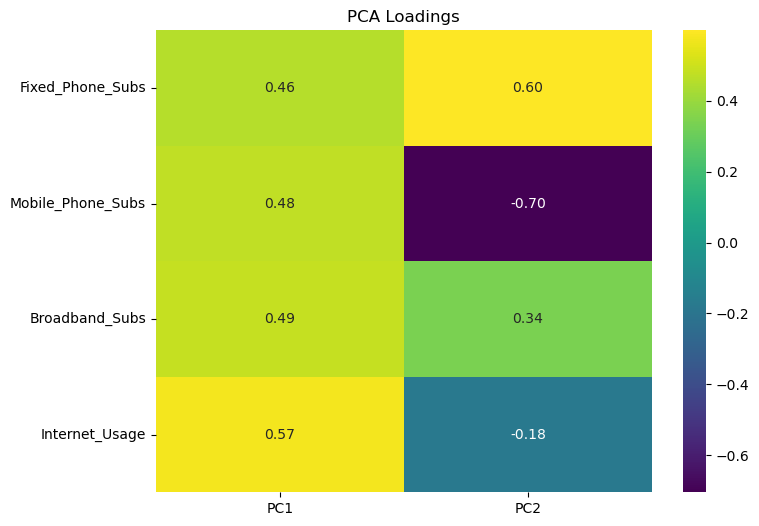

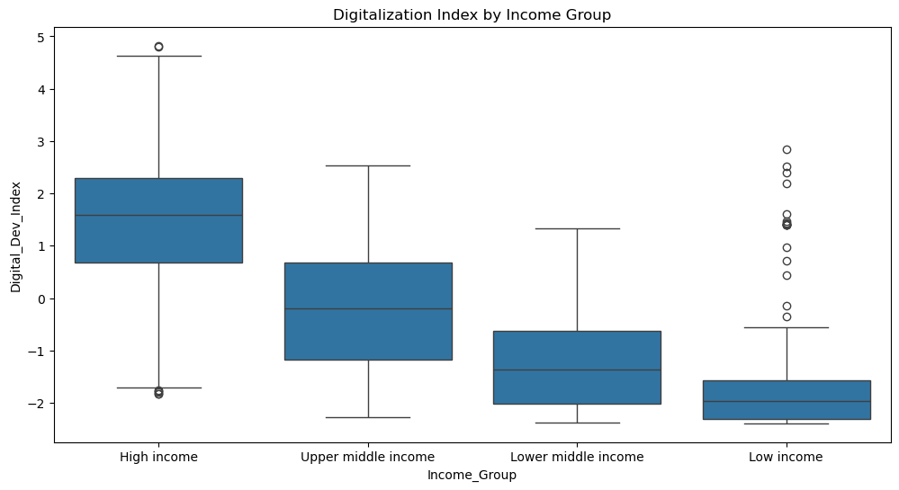

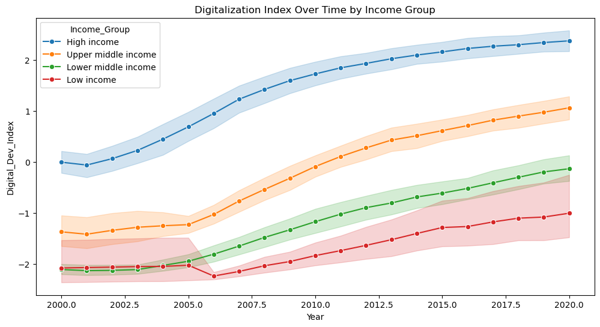

```python
import pandas as pd
from sklearn.decomposition import PCA
from sklearn.preprocessing import StandardScaler
import matplotlib.pyplot as plt
import seaborn as sns

# 1. Data Preprocessing and Standardization
def preprocess_and_pca(df):
    # Create income level mapping


    # Standardize digital indicators
    digital_cols = ['Fixed_Phone_Subs', 'Mobile_Phone_Subs', 'Broadband_Subs', 'Internet_Usage']
    scaler = StandardScaler()
    df[digital_cols] = scaler.fit_transform(df[digital_cols])

    # Apply PCA to reduce dimensionality
    pca = PCA(n_components=2)  # Reducing to 2 components for simplicity
    principal_components = pca.fit_transform(df[digital_cols])

    # Add PCA components to the dataframe
    df['PC1'], df['PC2'] = principal_components[:, 0], principal_components[:, 1]

    # Calculate the Digitalization Index (using the first principal component)
    df['Digital_Dev_Index'] = df['PC1']

    # Explained variance of each principal component
    explained_variance = pca.explained_variance_ratio_
    print(f"Explained Variance: {explained_variance}")

    # Visualize the PCA loadings (how each feature contributes to the components)
    pca_loadings = pd.DataFrame(pca.components_, columns=digital_cols, index=['PC1', 'PC2'])
    plt.figure(figsize=(8, 6))
    sns.heatmap(pca_loadings.T, annot=True, cmap='viridis', fmt='.2f')
    plt.title("PCA Loadings")
    plt.show()

    return df, explained_variance

# 2. Visualizations
def visualize_digitalization_index(df):
    # Visualizing the Digitalization Index across income groups
    plt.figure(figsize=(12, 6))
    sns.boxplot(x='Income_Group', y='Digital_Dev_Index', data=df)
    plt.title('Digitalization Index by Income Group')
    plt.show()

    # Visualizing Digitalization Index over years
    plt.figure(figsize=(12, 6))
    sns.lineplot(x='Year', y='Digital_Dev_Index', hue='Income_Group', data=df, marker='o')
    plt.title('Digitalization Index Over Time by Income Group')
    plt.show()

# Preprocess the data and apply PCA
df, explained_variance = preprocess_and_pca(df)

# Visualize the Digitalization Index
visualize_digitalization_index(df)
```

## **Understanding the Digital Development Index (DDI)**

The **Digital Development Index (DDI)**, derived from **Principal Component Analysis (PCA)**, is a powerful tool for understanding and comparing digital infrastructure and adoption across different countries, regions, and income groups. Let's delve deeper into why this index matters:

### **1. Data Reduction and Interpretation 📊**

PCA allows us to condense multiple indicators of digital development into a single, more manageable index. This reduction simplifies the data without losing critical information. Here's how different factors contribute to the index:

- **Internet Usage** has the highest loading (0.57) on **PC1**, indicating its strong influence on the overall index.
- **Fixed Phone Subscriptions**, **Mobile Phone Subscriptions**, and **Broadband Subscriptions** also contribute significantly to **PC1** (0.46, 0.48, and 0.49, respectively).
- **PC2** provides additional nuance, with **Fixed Phone Subscriptions** (0.60) contrasting against **Mobile Phone Subscriptions** (-0.70).

This reduction allows policymakers and researchers to work with a more concise measure while retaining most of the information from the original variables, enabling better decision-making and analysis.

### **2. Digitalization Comparison 🌍**

The **Digital Development Index** makes it easy to compare digitalization levels across different groups:

- The **box plot** clearly shows a strong correlation between income levels and digital development:
  - **High-income countries** have the highest median DDI, with the box entirely above zero, reflecting their advanced digital infrastructure.
  - There's a **stepwise decrease** in DDI as we move from high-income to low-income groups.
  - **Low-income countries** show the lowest median DDI, with most of their distribution below zero, indicating a lag in digital infrastructure and adoption.

This ability to compare digitalization levels across income groups is crucial for:

- **Identifying digital divides** between different economic groups 🌐
- **Tracking progress** in digital development over time 📅
- **Setting benchmarks** and goals for improving digital infrastructure and promoting digital inclusion 🏗️

### **Conclusion 🏁**

The Digital Development Index, powered by PCA, offers an effective means of summarizing and comparing digital development across various regions and income levels. By reducing the complexity of multiple indicators into a single, interpretable index, it provides invaluable insights for policymakers, researchers, and international organizations aiming to bridge the digital divide and foster global economic development.

|  | Income_Level | Continent | Country_Count | Country_Name | Country_Code | Year | ID | Income_Value | Log_GDP | Fixed_Phone_Subs | ... | Trade_Openness | Labor_Force | Consumer_Price_Index | Population | Govt_Consumption | Research_Dev | Period | Income_Group | PC1 | PC2 |
| --- | --- | --- | --- | --- | --- | --- | --- | --- | --- | --- | --- | --- | --- | --- | --- | --- | --- | --- | --- | --- | --- |
| 0 | High Income | Europe | 1.0 | Netherlands | Pays Bas | 2000 | 1 | 1 | 10.607994 | 2.145839 | ... | 1.255219 | 1.27381 | 4.406078 | 16.583433 | 0.364773 | 0.017898 | 2000-2005 | High income | 0.636626 | 1.228047 |
| 1 | High Income | Europe | 1.0 | Netherlands | Pays Bas | 2001 | 1 | 1 | 10.623448 | 1.563458 | ... | 1.275219 | 1.28668 | 4.446796 | 16.590981 | 0.369977 | 0.017961 | 2000-2005 | High income | 0.435480 | 0.883361 |
| 2 | High Income | Europe | 1.0 | Netherlands | Pays Bas | 2002 | 1 | 1 | 10.619236 | 1.505498 | ... | 1.295219 | 1.30062 | 4.479143 | 16.597364 | 0.372896 | 0.017454 | 2000-2005 | High income | 0.473476 | 0.852997 |
| 3 | High Income | Europe | 1.0 | Netherlands | Pays Bas | 2003 | 1 | 1 | 10.616073 | 1.432999 | ... | 1.315219 | 1.29774 | 4.499847 | 16.602082 | 0.382046 | 0.017839 | 2000-2005 | High income | 0.504841 | 0.813918 |
| 4 | High Income | Europe | 1.0 | Netherlands | Pays Bas | 2004 | 1 | 1 | 10.632253 | 1.424427 | ... | 1.335219 | 1.30060 | 4.512404 | 16.605557 | 0.374042 | 0.017890 | 2000-2005 | High income | 0.565358 | 0.813155 |

5 rows × 25 columns

```
Data dimensions: (2730, 25)

Data info:
<class 'pandas.core.frame.DataFrame'>
RangeIndex: 2730 entries, 0 to 2729
Data columns (total 25 columns):
 #   Column                Non-Null Count  Dtype
---  ------                --------------  -----
 0   Income_Level          2730 non-null   object
 1   Continent             2730 non-null   object
 2   Country_Count         2730 non-null   float64
 3   Country_Name          2730 non-null   object
 4   Country_Code          2730 non-null   object
 5   Year                  2730 non-null   int64
 6   ID                    2730 non-null   int64
 7   Income_Value          2730 non-null   int64
 8   Log_GDP               2730 non-null   float64
 9   Fixed_Phone_Subs      2730 non-null   float64
 10  Mobile_Phone_Subs     2730 non-null   float64
 11  Broadband_Subs        2730 non-null   float64
 12  Internet_Usage        2730 non-null   float64
 13  Digital_Dev_Index     2730 non-null   float64
 14  Capital_Formation     2730 non-null   float64
 15  Trade_Openness        2730 non-null   float64
 16  Labor_Force           2730 non-null   float64
 17  Consumer_Price_Index  2729 non-null   float64
 18  Population            2730 non-null   float64
 19  Govt_Consumption      2730 non-null   float64
 20  Research_Dev          2730 non-null   float64
 21  Period                2730 non-null   category
 22  Income_Group          2730 non-null   object
 23  PC1                   2730 non-null   float64
 24  PC2                   2730 non-null   float64
dtypes: category(1), float64(16), int64(3), object(5)
memory usage: 514.9+ KB

Summary statistics for numerical variables:
```

|  | Country_Count | Year | ID | Income_Value | Log_GDP | Fixed_Phone_Subs | Mobile_Phone_Subs | Broadband_Subs | Internet_Usage | Digital_Dev_Index | Capital_Formation | Trade_Openness | Labor_Force | Consumer_Price_Index | Population | Govt_Consumption | Research_Dev | PC1 | PC2 |
| --- | --- | --- | --- | --- | --- | --- | --- | --- | --- | --- | --- | --- | --- | --- | --- | --- | --- | --- | --- |
| count | 2730.000000 | 2730.00000 | 2730.000000 | 2730.000000 | 2730.000000 | 2.730000e+03 | 2730.000000 | 2730.000000 | 2.730000e+03 | 2730.000000 | 2730.000000 | 2730.000000 | 2730.000000 | 2729.000000 | 2730.000000 | 2730.000000 | 2730.000000 | 2730.000000 | 2.730000e+03 |
| mean | 7.338462 | 2010.00000 | 65.500000 | 2.084615 | 8.678145 | -4.164353e-17 | 0.000000 | 0.000000 | 4.164353e-17 | 0.000000 | 0.245509 | 0.883384 | 1.246620 | 4.583226 | 16.297923 | 0.263832 | 0.007835 | 0.000000 | -4.164353e-17 |
| std | 7.114188 | 6.05641 | 37.533532 | 1.030757 | 1.477015 | 1.000183e+00 | 1.000183 | 1.000183 | 1.000183e+00 | 1.625221 | 0.075200 | 0.562682 | 0.205700 | 0.375803 | 1.688415 | 0.134054 | 0.008876 | 1.625221 | 8.396756e-01 |
| min | 1.000000 | 2000.00000 | 1.000000 | 1.000000 | 5.555394 | -1.093622e+00 | -1.683760 | -0.792459 | -1.233149e+00 | -2.390264 | 0.015252 | 0.195596 | 0.749380 | 1.067838 | 4.066614 | 0.000000 | 0.000054 | -2.390264 | -2.514773e+00 |
| 25% | 2.000000 | 2005.00000 | 33.000000 | 1.000000 | 7.587988 | -8.738267e-01 | -0.845574 | -0.772069 | -9.848710e-01 | -1.475125 | 0.198568 | 0.546072 | 1.125810 | 4.418691 | 15.265082 | 0.168977 | 0.001792 | -1.475125 | -6.206586e-01 |
| 50% | 5.000000 | 2010.00000 | 65.500000 | 2.000000 | 8.606205 | -2.720426e-01 | 0.115310 | -0.477401 | -1.584913e-01 | -0.127971 | 0.234834 | 0.755584 | 1.232915 | 4.605170 | 16.184073 | 0.251409 | 0.004333 | -0.127971 | 4.826773e-02 |
| 75% | 10.000000 | 2015.00000 | 98.000000 | 3.000000 | 9.900314 | 6.508028e-01 | 0.743054 | 0.625611 | 8.963164e-01 | 1.368638 | 0.280631 | 1.044083 | 1.353140 | 4.754252 | 17.421507 | 0.340486 | 0.010179 | 1.368638 | 5.314388e-01 |
| max | 31.000000 | 2020.00000 | 130.000000 | 4.000000 | 11.629978 | 3.695732e+00 | 4.326454 | 6.989539 | 2.058299e+00 | 4.824238 | 0.601562 | 4.426200 | 1.767370 | 7.910338 | 21.067514 | 1.651000 | 0.049408 | 4.824238 | 3.108233e+00 |

```
Missing values per column:
```

```
Income_Level            0
Continent               0
Country_Count           0
Country_Name            0
Country_Code            0
Year                    0
ID                      0
Income_Value            0
Log_GDP                 0
Fixed_Phone_Subs        0
Mobile_Phone_Subs       0
Broadband_Subs          0
Internet_Usage          0
Digital_Dev_Index       0
Capital_Formation       0
Trade_Openness          0
Labor_Force             0
Consumer_Price_Index    1
Population              0
Govt_Consumption        0
Research_Dev            0
Period                  0
Income_Group            0
PC1                     0
PC2                     0
dtype: int64
```

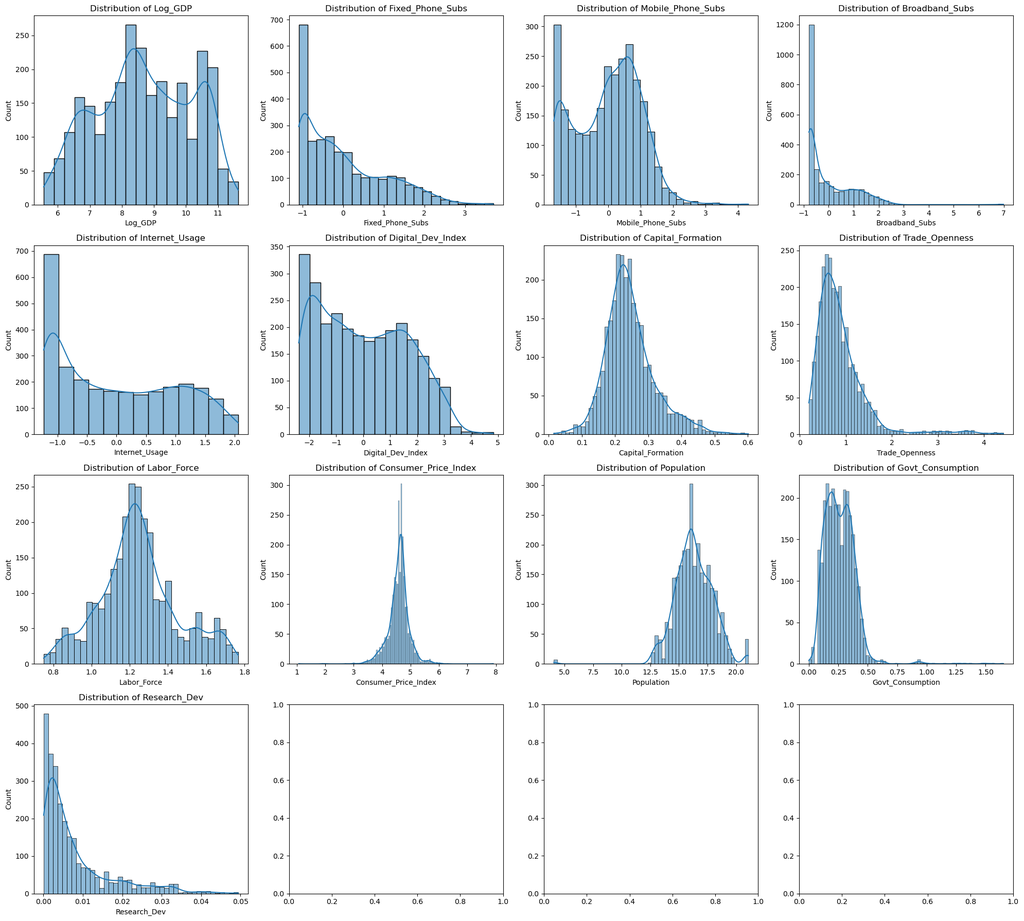

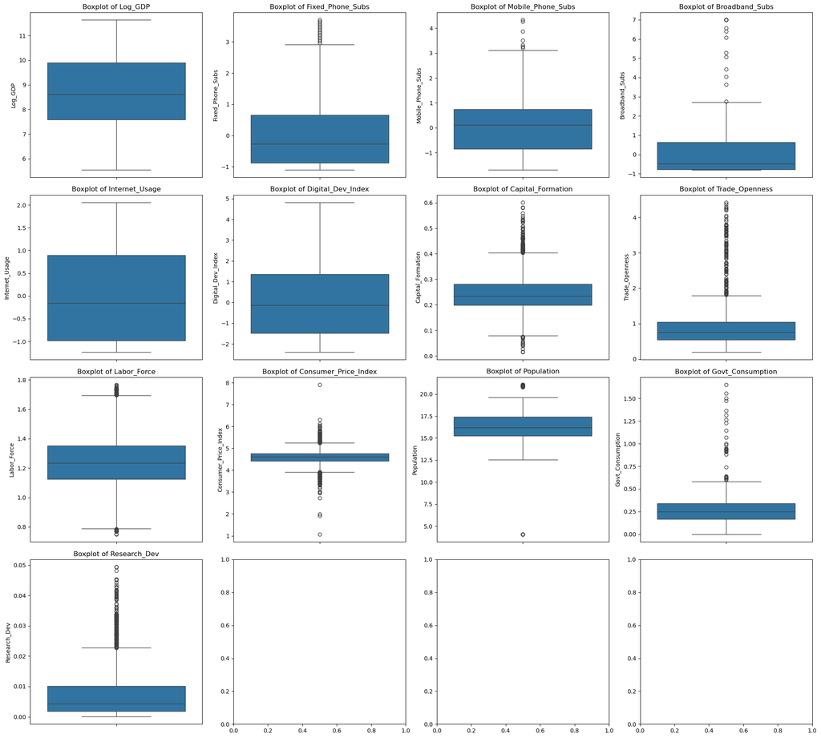

```
Descriptive statistics by Income Level:
```

|  | Income_Level | High Income | Low income | Lower middle income | Upper middle income |
| --- | --- | --- | --- | --- | --- |
| Log_GDP | count | 1050.000000 | 294.000000 | 693.000000 | 693.000000 |
|  | mean | 10.200978 | 6.291799 | 7.469222 | 8.592136 |
|  | std | 0.656655 | 0.352855 | 0.549149 | 0.431565 |
|  | min | 8.422575 | 5.555394 | 6.187322 | 7.162308 |
|  | 25% | 9.723449 | 6.004896 | 7.029209 | 8.324530 |
| ... | ... | ... | ... | ... | ... |
| Research_Dev | min | 0.000307 | 0.000109 | 0.000054 | 0.000152 |
|  | 25% | 0.005548 | 0.001011 | 0.001022 | 0.001701 |
|  | 50% | 0.012513 | 0.002131 | 0.002518 | 0.003632 |
|  | 75% | 0.021637 | 0.003146 | 0.004411 | 0.007078 |
|  | max | 0.049408 | 0.006466 | 0.011129 | 0.021406 |

104 rows × 4 columns

```
Descriptive statistics by Continent:
```

|  | Continent | Africa | Americas | Arab States | Asia and Pacific | CIS | Europe |
| --- | --- | --- | --- | --- | --- | --- | --- |
| Log_GDP | count | 630.000000 | 420.000000 | 252.000000 | 441.000000 | 126.000000 | 861.000000 |
|  | mean | 7.040228 | 8.951935 | 9.281323 | 8.510386 | 7.958420 | 9.757777 |
|  | std | 0.904079 | 0.823000 | 1.094085 | 1.439660 | 0.988258 | 1.037959 |
|  | min | 5.555394 | 7.483200 | 7.474999 | 6.187322 | 6.073838 | 7.199128 |
|  | 25% | 6.397596 | 8.355333 | 8.257154 | 7.303491 | 6.989693 | 8.979924 |
| ... | ... | ... | ... | ... | ... | ... | ... |
| Research_Dev | min | 0.000054 | 0.000150 | 0.000423 | 0.000371 | 0.000670 | 0.000152 |
|  | 25% | 0.001322 | 0.000663 | 0.002197 | 0.001276 | 0.001436 | 0.005612 |
|  | 50% | 0.002782 | 0.002179 | 0.005090 | 0.004176 | 0.002093 | 0.011307 |
|  | 75% | 0.004064 | 0.004427 | 0.007078 | 0.012523 | 0.002670 | 0.019986 |
|  | max | 0.008981 | 0.028328 | 0.012784 | 0.045275 | 0.012860 | 0.049408 |

104 rows × 6 columns

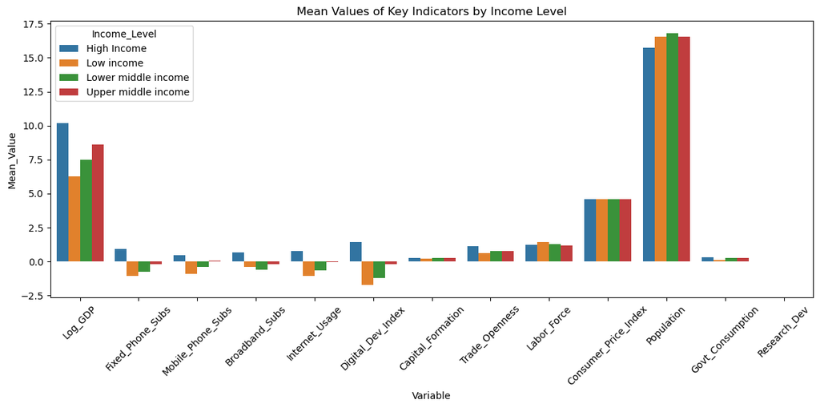

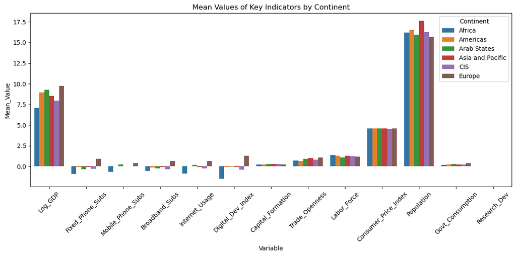

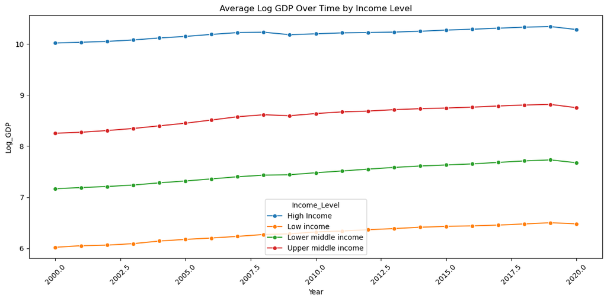

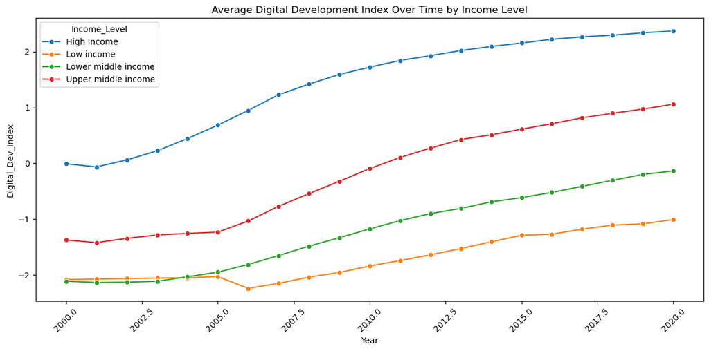

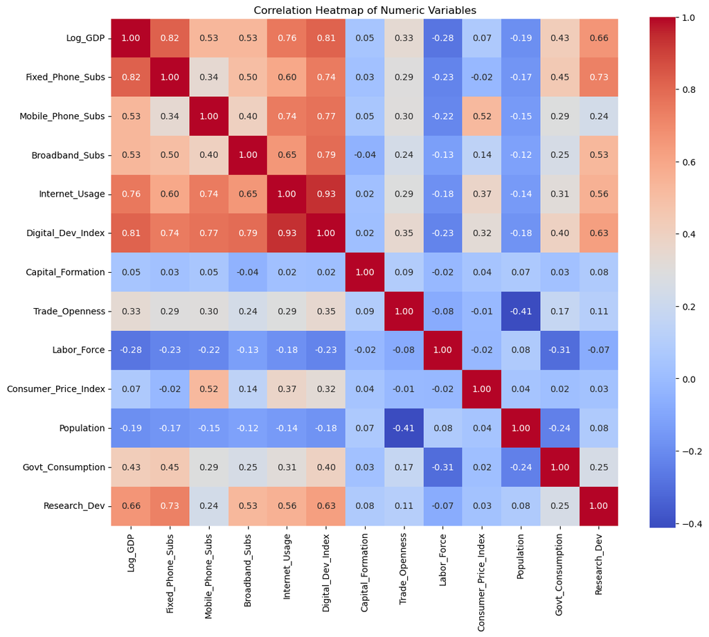

```
Country Clusters based on Mean Digitalization & GDP metrics:
```

| Country_Name | Log_GDP | Digital_Dev_Index | Capital_Formation | Trade_Openness | Cluster |
| --- | --- | --- | --- | --- | --- |
| Albania | 8.093315 | -0.364748 | 0.303554 | 0.732310 | 1 |
| Algeria | 8.246992 | -0.844716 | 0.390280 | 0.632354 | 1 |
| Angola | 8.159068 | -1.864352 | 0.276881 | 0.950902 | 1 |
| Argentina | 9.410739 | 0.349768 | 0.168961 | 0.328283 | 2 |
| Armenia | 7.943360 | -0.414006 | 0.282623 | 0.726467 | 1 |
| Australia | 10.879736 | 1.756688 | 0.260627 | 0.420266 | 2 |
| Austria | 10.668779 | 1.852346 | 0.243034 | 0.980747 | 2 |
| Azerbaijan | 8.240264 | -0.226821 | 0.273408 | 0.876964 | 1 |
| Bahrain | 9.994502 | 0.747671 | 0.272278 | 1.466504 | 2 |
| Bangladesh | 6.903897 | -1.699441 | 0.273227 | 0.373848 | 1 |

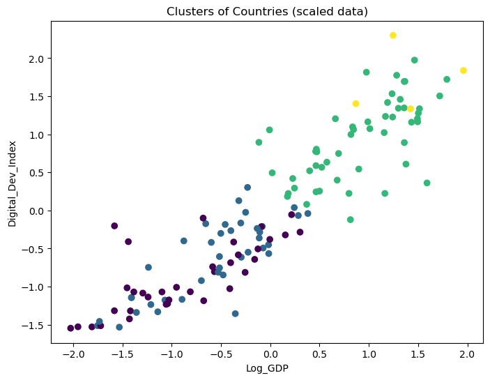

```python
import pandas as pd
import numpy as np
import matplotlib.pyplot as plt
import seaborn as sns


display(df.head())

# Data dimensions
print("Data dimensions:", df.shape)

# Data info
print("\nData info:")
df.info()

# Summary statistics for numerical variables
print("\nSummary statistics for numerical variables:")
display(df.describe())

# Check for missing values
print("\nMissing values per column:")
display(df.isna().sum())

# ------------------------------------------------------------
# Distributions and Descriptive Analysis
# ------------------------------------------------------------

# List of key numeric variables we want to explore
numeric_vars = ["Log_GDP", "Fixed_Phone_Subs", "Mobile_Phone_Subs", "Broadband_Subs",
                "Internet_Usage", "Digital_Dev_Index", "Capital_Formation",
                "Trade_Openness", "Labor_Force", "Consumer_Price_Index",
                "Population", "Govt_Consumption", "Research_Dev"]

# Histograms for numeric variables
fig, axes = plt.subplots(nrows=4, ncols=4, figsize=(20, 18))
axes = axes.flatten()

for i, var in enumerate(numeric_vars):
    sns.histplot(df[var], kde=True, ax=axes[i])
    axes[i].set_title(f"Distribution of {var}")

# Adjust layout
plt.tight_layout()
plt.show()

# Boxplots to check for outliers
fig, axes = plt.subplots(nrows=4, ncols=4, figsize=(20, 18))
axes = axes.flatten()

for i, var in enumerate(numeric_vars):
    sns.boxplot(y=df[var], ax=axes[i])
    axes[i].set_title(f"Boxplot of {var}")

plt.tight_layout()
plt.show()

# ------------------------------------------------------------
# Grouped Analysis: By Income Level & Continent
# ------------------------------------------------------------

# Group descriptive statistics by Income_Level
income_group_stats = df.groupby("Income_Level")[numeric_vars].describe().T
print("\nDescriptive statistics by Income Level:")
display(income_group_stats)

# Group descriptive statistics by Continent
continent_group_stats = df.groupby("Continent")[numeric_vars].describe().T
print("\nDescriptive statistics by Continent:")
display(continent_group_stats)

# Compare means of key variables by Income_Level with bar charts
mean_by_income = df.groupby("Income_Level")[numeric_vars].mean().reset_index()
mean_by_income = mean_by_income.melt(id_vars="Income_Level", var_name="Variable", value_name="Mean_Value")

plt.figure(figsize=(12,6))
sns.barplot(x="Variable", y="Mean_Value", hue="Income_Level", data=mean_by_income)
plt.title("Mean Values of Key Indicators by Income Level")
plt.xticks(rotation=45)
plt.tight_layout()
plt.show()

# Compare means of key variables by Continent with bar charts
mean_by_continent = df.groupby("Continent")[numeric_vars].mean().reset_index()
mean_by_continent = mean_by_continent.melt(id_vars="Continent", var_name="Variable", value_name="Mean_Value")

plt.figure(figsize=(12,6))
sns.barplot(x="Variable", y="Mean_Value", hue="Continent", data=mean_by_continent)
plt.title("Mean Values of Key Indicators by Continent")
plt.xticks(rotation=45)
plt.tight_layout()
plt.show()

# ------------------------------------------------------------
# Time Trends
# ------------------------------------------------------------

# For time series analysis, we assume "Year" is available
# Plot average GDP and Digitalization level over time by Income Level
avg_by_year_income = df.groupby(["Year", "Income_Level"])[["Log_GDP", "Digital_Dev_Index"]].mean().reset_index()

plt.figure(figsize=(12,6))
sns.lineplot(x="Year", y="Log_GDP", hue="Income_Level", data=avg_by_year_income, marker="o")
plt.title("Average Log GDP Over Time by Income Level")
plt.xticks(rotation=45)
plt.tight_layout()
plt.show()

plt.figure(figsize=(12,6))
sns.lineplot(x="Year", y="Digital_Dev_Index", hue="Income_Level", data=avg_by_year_income, marker="o")
plt.title("Average Digital Development Index Over Time by Income Level")
plt.xticks(rotation=45)
plt.tight_layout()
plt.show()

# ------------------------------------------------------------
# Correlation Analysis
# ------------------------------------------------------------

# Correlation matrix of numeric variables
corr_matrix = df[numeric_vars].corr()

plt.figure(figsize=(12,10))
sns.heatmap(corr_matrix, annot=True, fmt=".2f", cmap="coolwarm", square=True)
plt.title("Correlation Heatmap of Numeric Variables")
plt.tight_layout()
plt.show()



from sklearn.preprocessing import StandardScaler
from sklearn.cluster import KMeans

cluster_vars = ["Log_GDP", "Digital_Dev_Index", "Capital_Formation", "Trade_Openness"]
cluster_data = df.groupby("Country_Name")[cluster_vars].mean().dropna()

scaler = StandardScaler()
X_scaled = scaler.fit_transform(cluster_data)

kmeans = KMeans(n_clusters=4, random_state=42)
cluster_labels = kmeans.fit_predict(X_scaled)

cluster_data["Cluster"] = cluster_labels

print("\nCountry Clusters based on Mean Digitalization & GDP metrics:")
display(cluster_data.head(10))

# Visualize clusters (optional)
plt.figure(figsize=(8,6))
plt.scatter(X_scaled[:,0], X_scaled[:,1], c=cluster_labels, cmap="viridis")
plt.title("Clusters of Countries (scaled data)")
plt.xlabel(cluster_vars[0])
plt.ylabel(cluster_vars[1])
plt.show()
```

## **Distribution Analysis** 📊

The following image shows distribution plots for multiple variables:

## **Boxplot Analysis** 📈

The following image presents boxplots for the same variables:

## **Continental Comparison** 🌍

The third image compares mean values across continents:

## **Correlation Analysis** 🔍

### **Strong Positive Correlations** 🔼:

- **Log GDP** with:
  - **Fixed Phone Subscriptions** (0.82) 📞
  - **Internet Usage** (0.76) 🌐
  - **Digital Development Index** (0.81) 📊
- **Internet Usage** with **Digital Development Index** (0.93) 📡

### **Moderate Positive Correlations** ➡️:

- **Mobile Phone Subscriptions** with:
  - **Internet Usage** (0.74) 📱
  - **Digital Development Index** (0.77) 📶
- **Broadband Subscriptions** with **Digital Development Index** (0.79) 🌍

### **Weak or Negative Correlations** 🔽:

- **Capital Formation** shows weak correlations with most variables 💸.
- **Labor Force** has weak negative correlations with several economic indicators 👥⬇️.

### **Key Insights** 📊:

- Strong interconnections between **economic output**, **technological adoption**, and **digital development** 💡.
- Surprisingly **weak correlation** between **population** and other variables 👤.
- **Consumer Price Index** shows moderate positive correlation with **Mobile Phone Subscriptions** (0.52) 📉📱.

```python
import pandas as pd
import numpy as np
import plotly.express as px
import plotly.graph_objects as go
from plotly.subplots import make_subplots
from sklearn.preprocessing import StandardScaler
from sklearn.cluster import KMeans

# ------------------------------------------------------------
# Basic Data Inspection
# ------------------------------------------------------------

# Check the first few rows of the data
display(df.head())

# Data dimensions
print("Data dimensions:", df.shape)

# Data info
print("\nData info:")
df.info()

# Summary statistics for numerical variables
print("\nSummary statistics for numerical variables:")
display(df.describe())

# Check for missing values
print("\nMissing values per column:")
display(df.isna().sum())

# ------------------------------------------------------------
# Distributions and Descriptive Analysis
# ------------------------------------------------------------

# List of key numeric variables we want to explore
numeric_vars = ["Log_GDP", "Fixed_Phone_Subs", "Mobile_Phone_Subs", "Broadband_Subs",
                "Internet_Usage", "Digital_Dev_Index", "Capital_Formation",
                "Trade_Openness", "Labor_Force", "Consumer_Price_Index",
                "Population", "Govt_Consumption", "Research_Dev"]

# Histograms for numeric variables (using Plotly for interactivity)
fig = make_subplots(rows=4, cols=4, subplot_titles=numeric_vars)
for i, var in enumerate(numeric_vars):
    row = i // 4 + 1
    col = i % 4 + 1
    fig.add_trace(
        go.Histogram(x=df[var], name=var),
        row=row, col=col
    )

fig.update_layout(
    height=1000,
    width=1000,
    title_text="Distribution of Numeric Variables",
    showlegend=False
)
fig.show()

# Boxplots to check for outliers (using Plotly)
fig = make_subplots(rows=4, cols=4, subplot_titles=numeric_vars)
for i, var in enumerate(numeric_vars):
    row = i // 4 + 1
    col = i % 4 + 1
    fig.add_trace(
        go.Box(y=df[var], name=var),
        row=row, col=col
    )

fig.update_layout(
    height=1000,
    width=1000,
    title_text="Boxplots of Numeric Variables",
    showlegend=False
)
fig.show()

# ------------------------------------------------------------
# Grouped Analysis: By Income Level & Continent
# ------------------------------------------------------------

# Group descriptive statistics by Income_Level
income_group_stats = df.groupby("Income_Level")[numeric_vars].describe().T
print("\nDescriptive statistics by Income Level:")
display(income_group_stats)

# Group descriptive statistics by Continent
continent_group_stats = df.groupby("Continent")[numeric_vars].describe().T
print("\nDescriptive statistics by Continent:")
display(continent_group_stats)

# Compare means of key variables by Income_Level with bar charts (using Plotly)
mean_by_income = df.groupby("Income_Level")[numeric_vars].mean().reset_index()
mean_by_income = mean_by_income.melt(id_vars="Income_Level", var_name="Variable", value_name="Mean_Value")

fig = px.bar(mean_by_income, x="Variable", y="Mean_Value", color="Income_Level",
             title="Mean Values of Key Indicators by Income Level")
fig.show()

# Compare means of key variables by Continent with bar charts (using Plotly)
mean_by_continent = df.groupby("Continent")[numeric_vars].mean().reset_index()
mean_by_continent = mean_by_continent.melt(id_vars="Continent", var_name="Variable", value_name="Mean_Value")

fig = px.bar(mean_by_continent, x="Variable", y="Mean_Value", color="Continent",
             title="Mean Values of Key Indicators by Continent")
fig.show()

# ------------------------------------------------------------
# Time Trends
# ------------------------------------------------------------

# For time series analysis, we assume "Year" is available
# Plot average GDP and Digitalization level over time by Income Level
avg_by_year_income = df.groupby(["Year", "Income_Level"])[["Log_GDP", "Digital_Dev_Index"]].mean().reset_index()

# Average Log GDP over time by Income Level (interactive plot)
fig = px.line(avg_by_year_income, x="Year", y="Log_GDP", color="Income_Level",
              markers=True, title="Average Log GDP Over Time by Income Level")
fig.show()

# Average Digital Development Index over time by Income Level (interactive plot)
fig = px.line(avg_by_year_income, x="Year", y="Digital_Dev_Index", color="Income_Level",
              markers=True, title="Average Digital Development Index Over Time by Income Level")
fig.show()

# ------------------------------------------------------------
# Correlation Analysis
# ------------------------------------------------------------

# Correlation matrix of numeric variables (using Plotly for interactivity)
# Correlation matrix of numeric variables
# Correlation matrix of numeric variables
corr_matrix = df[numeric_vars].corr()

# Convert correlation matrix to DataFrame (for compatibility with plotly)
corr_matrix_df = pd.DataFrame(corr_matrix)

# Plot the correlation heatmap using Plotly
fig = px.imshow(corr_matrix_df, text_auto=True, color_continuous_scale="Viridis",
                title="Correlation Heatmap of Numeric Variables")

# Display the heatmap
fig.show()

cluster_vars = ["Log_GDP", "Digital_Dev_Index", "Capital_Formation", "Trade_Openness"]
cluster_data = df.groupby("Country_Name")[cluster_vars].mean().dropna()

scaler = StandardScaler()
X_scaled = scaler.fit_transform(cluster_data)

kmeans = KMeans(n_clusters=4, random_state=42)
cluster_labels = kmeans.fit_predict(X_scaled)

cluster_data["Cluster"] = cluster_labels

print("\nCountry Clusters based on Mean Digitalization & GDP metrics:")
display(cluster_data.head(10))

# Visualize clusters (interactive plot with Plotly)
fig = px.scatter(cluster_data, x=cluster_vars[0], y=cluster_vars[1], color="Cluster",
                 title="Clusters of Countries Based on Digitalization & GDP")
fig.show()
```

|  | Income_Level | Continent | Country_Count | Country_Name | Country_Code | Year | ID | Income_Value | Log_GDP | Fixed_Phone_Subs | ... | Trade_Openness | Labor_Force | Consumer_Price_Index | Population | Govt_Consumption | Research_Dev | Period | Income_Group | PC1 | PC2 |
| --- | --- | --- | --- | --- | --- | --- | --- | --- | --- | --- | --- | --- | --- | --- | --- | --- | --- | --- | --- | --- | --- |
| 0 | High Income | Europe | 1.0 | Netherlands | Pays Bas | 2000 | 1 | 1 | 10.607994 | 2.145839 | ... | 1.255219 | 1.27381 | 4.406078 | 16.583433 | 0.364773 | 0.017898 | 2000-2005 | High income | 0.636626 | 1.228047 |
| 1 | High Income | Europe | 1.0 | Netherlands | Pays Bas | 2001 | 1 | 1 | 10.623448 | 1.563458 | ... | 1.275219 | 1.28668 | 4.446796 | 16.590981 | 0.369977 | 0.017961 | 2000-2005 | High income | 0.435480 | 0.883361 |
| 2 | High Income | Europe | 1.0 | Netherlands | Pays Bas | 2002 | 1 | 1 | 10.619236 | 1.505498 | ... | 1.295219 | 1.30062 | 4.479143 | 16.597364 | 0.372896 | 0.017454 | 2000-2005 | High income | 0.473476 | 0.852997 |
| 3 | High Income | Europe | 1.0 | Netherlands | Pays Bas | 2003 | 1 | 1 | 10.616073 | 1.432999 | ... | 1.315219 | 1.29774 | 4.499847 | 16.602082 | 0.382046 | 0.017839 | 2000-2005 | High income | 0.504841 | 0.813918 |
| 4 | High Income | Europe | 1.0 | Netherlands | Pays Bas | 2004 | 1 | 1 | 10.632253 | 1.424427 | ... | 1.335219 | 1.30060 | 4.512404 | 16.605557 | 0.374042 | 0.017890 | 2000-2005 | High income | 0.565358 | 0.813155 |

5 rows × 25 columns

```
Data dimensions: (2730, 25)

Data info:
<class 'pandas.core.frame.DataFrame'>
RangeIndex: 2730 entries, 0 to 2729
Data columns (total 25 columns):
 #   Column                Non-Null Count  Dtype
---  ------                --------------  -----
 0   Income_Level          2730 non-null   object
 1   Continent             2730 non-null   object
 2   Country_Count         2730 non-null   float64
 3   Country_Name          2730 non-null   object
 4   Country_Code          2730 non-null   object
 5   Year                  2730 non-null   int64
 6   ID                    2730 non-null   int64
 7   Income_Value          2730 non-null   int64
 8   Log_GDP               2730 non-null   float64
 9   Fixed_Phone_Subs      2730 non-null   float64
 10  Mobile_Phone_Subs     2730 non-null   float64
 11  Broadband_Subs        2730 non-null   float64
 12  Internet_Usage        2730 non-null   float64
 13  Digital_Dev_Index     2730 non-null   float64
 14  Capital_Formation     2730 non-null   float64
 15  Trade_Openness        2730 non-null   float64
 16  Labor_Force           2730 non-null   float64
 17  Consumer_Price_Index  2729 non-null   float64
 18  Population            2730 non-null   float64
 19  Govt_Consumption      2730 non-null   float64
 20  Research_Dev          2730 non-null   float64
 21  Period                2730 non-null   category
 22  Income_Group          2730 non-null   object
 23  PC1                   2730 non-null   float64
 24  PC2                   2730 non-null   float64
dtypes: category(1), float64(16), int64(3), object(5)
memory usage: 514.9+ KB

Summary statistics for numerical variables:
```

|  | Country_Count | Year | ID | Income_Value | Log_GDP | Fixed_Phone_Subs | Mobile_Phone_Subs | Broadband_Subs | Internet_Usage | Digital_Dev_Index | Capital_Formation | Trade_Openness | Labor_Force | Consumer_Price_Index | Population | Govt_Consumption | Research_Dev | PC1 | PC2 |
| --- | --- | --- | --- | --- | --- | --- | --- | --- | --- | --- | --- | --- | --- | --- | --- | --- | --- | --- | --- |
| count | 2730.000000 | 2730.00000 | 2730.000000 | 2730.000000 | 2730.000000 | 2.730000e+03 | 2730.000000 | 2730.000000 | 2.730000e+03 | 2730.000000 | 2730.000000 | 2730.000000 | 2730.000000 | 2729.000000 | 2730.000000 | 2730.000000 | 2730.000000 | 2730.000000 | 2.730000e+03 |
| mean | 7.338462 | 2010.00000 | 65.500000 | 2.084615 | 8.678145 | -4.164353e-17 | 0.000000 | 0.000000 | 4.164353e-17 | 0.000000 | 0.245509 | 0.883384 | 1.246620 | 4.583226 | 16.297923 | 0.263832 | 0.007835 | 0.000000 | -4.164353e-17 |
| std | 7.114188 | 6.05641 | 37.533532 | 1.030757 | 1.477015 | 1.000183e+00 | 1.000183 | 1.000183 | 1.000183e+00 | 1.625221 | 0.075200 | 0.562682 | 0.205700 | 0.375803 | 1.688415 | 0.134054 | 0.008876 | 1.625221 | 8.396756e-01 |
| min | 1.000000 | 2000.00000 | 1.000000 | 1.000000 | 5.555394 | -1.093622e+00 | -1.683760 | -0.792459 | -1.233149e+00 | -2.390264 | 0.015252 | 0.195596 | 0.749380 | 1.067838 | 4.066614 | 0.000000 | 0.000054 | -2.390264 | -2.514773e+00 |
| 25% | 2.000000 | 2005.00000 | 33.000000 | 1.000000 | 7.587988 | -8.738267e-01 | -0.845574 | -0.772069 | -9.848710e-01 | -1.475125 | 0.198568 | 0.546072 | 1.125810 | 4.418691 | 15.265082 | 0.168977 | 0.001792 | -1.475125 | -6.206586e-01 |
| 50% | 5.000000 | 2010.00000 | 65.500000 | 2.000000 | 8.606205 | -2.720426e-01 | 0.115310 | -0.477401 | -1.584913e-01 | -0.127971 | 0.234834 | 0.755584 | 1.232915 | 4.605170 | 16.184073 | 0.251409 | 0.004333 | -0.127971 | 4.826773e-02 |
| 75% | 10.000000 | 2015.00000 | 98.000000 | 3.000000 | 9.900314 | 6.508028e-01 | 0.743054 | 0.625611 | 8.963164e-01 | 1.368638 | 0.280631 | 1.044083 | 1.353140 | 4.754252 | 17.421507 | 0.340486 | 0.010179 | 1.368638 | 5.314388e-01 |
| max | 31.000000 | 2020.00000 | 130.000000 | 4.000000 | 11.629978 | 3.695732e+00 | 4.326454 | 6.989539 | 2.058299e+00 | 4.824238 | 0.601562 | 4.426200 | 1.767370 | 7.910338 | 21.067514 | 1.651000 | 0.049408 | 4.824238 | 3.108233e+00 |

```
Missing values per column:
```

```
Income_Level            0
Continent               0
Country_Count           0
Country_Name            0
Country_Code            0
Year                    0
ID                      0
Income_Value            0
Log_GDP                 0
Fixed_Phone_Subs        0
Mobile_Phone_Subs       0
Broadband_Subs          0
Internet_Usage          0
Digital_Dev_Index       0
Capital_Formation       0
Trade_Openness          0
Labor_Force             0
Consumer_Price_Index    1
Population              0
Govt_Consumption        0
Research_Dev            0
Period                  0
Income_Group            0
PC1                     0
PC2                     0
dtype: int64
```

```
Descriptive statistics by Income Level:
```

|  | Income_Level | High Income | Low income | Lower middle income | Upper middle income |
| --- | --- | --- | --- | --- | --- |
| Log_GDP | count | 1050.000000 | 294.000000 | 693.000000 | 693.000000 |
|  | mean | 10.200978 | 6.291799 | 7.469222 | 8.592136 |
|  | std | 0.656655 | 0.352855 | 0.549149 | 0.431565 |
|  | min | 8.422575 | 5.555394 | 6.187322 | 7.162308 |
|  | 25% | 9.723449 | 6.004896 | 7.029209 | 8.324530 |
| ... | ... | ... | ... | ... | ... |
| Research_Dev | min | 0.000307 | 0.000109 | 0.000054 | 0.000152 |
|  | 25% | 0.005548 | 0.001011 | 0.001022 | 0.001701 |
|  | 50% | 0.012513 | 0.002131 | 0.002518 | 0.003632 |
|  | 75% | 0.021637 | 0.003146 | 0.004411 | 0.007078 |
|  | max | 0.049408 | 0.006466 | 0.011129 | 0.021406 |

104 rows × 4 columns

```
Descriptive statistics by Continent:
```

|  | Continent | Africa | Americas | Arab States | Asia and Pacific | CIS | Europe |
| --- | --- | --- | --- | --- | --- | --- | --- |
| Log_GDP | count | 630.000000 | 420.000000 | 252.000000 | 441.000000 | 126.000000 | 861.000000 |
|  | mean | 7.040228 | 8.951935 | 9.281323 | 8.510386 | 7.958420 | 9.757777 |
|  | std | 0.904079 | 0.823000 | 1.094085 | 1.439660 | 0.988258 | 1.037959 |
|  | min | 5.555394 | 7.483200 | 7.474999 | 6.187322 | 6.073838 | 7.199128 |
|  | 25% | 6.397596 | 8.355333 | 8.257154 | 7.303491 | 6.989693 | 8.979924 |
| ... | ... | ... | ... | ... | ... | ... | ... |
| Research_Dev | min | 0.000054 | 0.000150 | 0.000423 | 0.000371 | 0.000670 | 0.000152 |
|  | 25% | 0.001322 | 0.000663 | 0.002197 | 0.001276 | 0.001436 | 0.005612 |
|  | 50% | 0.002782 | 0.002179 | 0.005090 | 0.004176 | 0.002093 | 0.011307 |
|  | 75% | 0.004064 | 0.004427 | 0.007078 | 0.012523 | 0.002670 | 0.019986 |
|  | max | 0.008981 | 0.028328 | 0.012784 | 0.045275 | 0.012860 | 0.049408 |

104 rows × 6 columns

```
Country Clusters based on Mean Digitalization & GDP metrics:
```

| Country_Name | Log_GDP | Digital_Dev_Index | Capital_Formation | Trade_Openness | Cluster |
| --- | --- | --- | --- | --- | --- |
| Albania | 8.093315 | -0.364748 | 0.303554 | 0.732310 | 1 |
| Algeria | 8.246992 | -0.844716 | 0.390280 | 0.632354 | 1 |
| Angola | 8.159068 | -1.864352 | 0.276881 | 0.950902 | 1 |
| Argentina | 9.410739 | 0.349768 | 0.168961 | 0.328283 | 2 |
| Armenia | 7.943360 | -0.414006 | 0.282623 | 0.726467 | 1 |
| Australia | 10.879736 | 1.756688 | 0.260627 | 0.420266 | 2 |
| Austria | 10.668779 | 1.852346 | 0.243034 | 0.980747 | 2 |
| Azerbaijan | 8.240264 | -0.226821 | 0.273408 | 0.876964 | 1 |
| Bahrain | 9.994502 | 0.747671 | 0.272278 | 1.466504 | 2 |
| Bangladesh | 6.903897 | -1.699441 | 0.273227 | 0.373848 | 1 |

```python
!pip install linearmodels
```

```python
import pandas as pd
import numpy as np
import statsmodels.api as sm
import statsmodels.formula.api as smf
from scipy.stats import f_oneway, ttest_ind
from linearmodels import PanelOLS, RandomEffects
from linearmodels.panel import compare
```

```python
required_cols = ["Country_Name", "Year", "Log_GDP", "Digital_Dev_Index",
                 "Capital_Formation", "Trade_Openness", "Labor_Force",
                 "Consumer_Price_Index", "Population", "Govt_Consumption"]

for col in required_cols:
    if col not in df.columns:
        raise ValueError(f"Missing required column: {col}")

# Set Country_Name and Year as a multi-index for panel data analysis
df_panel = df.set_index(["Country_Name", "Year"]).sort_index()
```

```python
income_mapping = {
    1: "High income",
    2: "Upper middle income",
    3: "Lower middle income",
    4: "Low income"
}
df["Income_Group"] = df["Income_Value"].map(income_mapping)

# ANOVA: Differences in Digital_Dev_Index by Income_Group
groups = df.groupby("Income_Group")["Digital_Dev_Index"].apply(list)
f_stat, p_val = f_oneway(*groups)
print("ANOVA for DDI across Income Groups:")
print("F-statistic:", f_stat, "p-value:", p_val)

# Interpretation:
# If p_val < 0.05, we can reject H0 and conclude that at least one group's mean DDI differs.
```

```
ANOVA for DDI across Income Groups:
F-statistic: 1147.0377666574598 p-value: 0.0
```

```python
high_income_ddi = df.loc[df["Income_Group"]=="High income", "Digital_Dev_Index"]
low_income_ddi = df.loc[df["Income_Group"]=="Low income", "Digital_Dev_Index"]
t_stat, p_val = ttest_ind(high_income_ddi, low_income_ddi, nan_policy='omit')
print("T-test between High and Low income DDI:")
print("t-statistic:", t_stat, "p-value:", p_val)
```

```
T-test between High and Low income DDI:
t-statistic: 41.56524643918178 p-value: 2.2181419866725824e-243
```

```python
reg_vars = ["Log_GDP", "Digital_Dev_Index", "Capital_Formation", "Trade_Openness",
            "Labor_Force", "Consumer_Price_Index", "Population", "Govt_Consumption"]

panel_data = df_panel[reg_vars].dropna()

# Add a constant
panel_data = panel_data.assign(const=1)

# Fixed Effects Model
fe_model = PanelOLS.from_formula(
    formula="Log_GDP ~ 1 + Digital_Dev_Index + Capital_Formation + Trade_Openness + Labor_Force + Consumer_Price_Index + Population + Govt_Consumption + EntityEffects + TimeEffects",
    data=panel_data
)
fe_results = fe_model.fit(cov_type='clustered', cluster_entity=True)
print("Fixed Effects Model Results:")
print(fe_results.summary)
```

```
Fixed Effects Model Results:
                          PanelOLS Estimation Summary
================================================================================
Dep. Variable:                Log_GDP   R-squared:                        0.1147
Estimator:                   PanelOLS   R-squared (Between):              0.0964
No. Observations:                2729   R-squared (Within):               0.4114
Date:                Fri, Dec 13 2024   R-squared (Overall):              0.1014
Time:                        20:47:42   Log-likelihood                    2078.6
Cov. Estimator:             Clustered
                                        F-statistic:                      47.607
Entities:                         130   P-value                           0.0000
Avg Obs:                       20.992   Distribution:                  F(7,2572)
Min Obs:                       20.000
Max Obs:                       21.000   F-statistic (robust):             4.8456
                                        P-value                           0.0000
Time periods:                      21   Distribution:                  F(7,2572)
Avg Obs:                       129.95
Min Obs:                       129.00
Max Obs:                       130.00

                                  Parameter Estimates
========================================================================================
                      Parameter  Std. Err.     T-stat    P-value    Lower CI    Upper CI
----------------------------------------------------------------------------------------
Intercept                9.2237     0.4602     20.044     0.0000      8.3214      10.126
Digital_Dev_Index        0.0390     0.0169     2.3092     0.0210      0.0059      0.0722
Capital_Formation        0.2303     0.1545     1.4904     0.1362     -0.0727      0.5334
Trade_Openness          -0.0710     0.0507    -1.4014     0.1612     -0.1703      0.0283
Labor_Force             -0.4541     0.2260    -2.0095     0.0446     -0.8972     -0.0110
Consumer_Price_Index     0.0969     0.0349     2.7785     0.0055      0.0285      0.1653
Population              -0.0273     0.0174    -1.5675     0.1171     -0.0615      0.0069
Govt_Consumption         0.1044     0.1195     0.8740     0.3822     -0.1299      0.3387
========================================================================================

F-test for Poolability: 826.72
P-value: 0.0000
Distribution: F(149,2572)

Included effects: Entity, Time
```

```python
re_model = RandomEffects.from_formula(
    formula="Log_GDP ~ 1 + Digital_Dev_Index + Capital_Formation + Trade_Openness + Labor_Force + Consumer_Price_Index + Population + Govt_Consumption",
    data=panel_data
)
re_results = re_model.fit(cov_type='clustered', cluster_entity=True)
print("Random Effects Model Results:")
print(re_results.summary)
```

```
Random Effects Model Results:
                        RandomEffects Estimation Summary
================================================================================
Dep. Variable:                Log_GDP   R-squared:                        0.5440
Estimator:              RandomEffects   R-squared (Between):              0.2217
No. Observations:                2729   R-squared (Within):               0.5828
Date:                Fri, Dec 13 2024   R-squared (Overall):              0.2275
Time:                        20:47:53   Log-likelihood                    1624.0
Cov. Estimator:             Clustered
                                        F-statistic:                      463.64
Entities:                         130   P-value                           0.0000
Avg Obs:                       20.992   Distribution:                  F(7,2721)
Min Obs:                       20.000
Max Obs:                       21.000   F-statistic (robust):             44.602
                                        P-value                           0.0000
Time periods:                      21   Distribution:                  F(7,2721)
Avg Obs:                       129.95
Min Obs:                       129.00
Max Obs:                       130.00

                                  Parameter Estimates
========================================================================================
                      Parameter  Std. Err.     T-stat    P-value    Lower CI    Upper CI
----------------------------------------------------------------------------------------
Intercept                8.8565     0.4424     20.018     0.0000      7.9889      9.7240
Digital_Dev_Index        0.1073     0.0145     7.4034     0.0000      0.0789      0.1357
Capital_Formation        0.3962     0.1498     2.6445     0.0082      0.1024      0.6900
Trade_Openness          -0.0044     0.0482    -0.0912     0.9273     -0.0990      0.0902
Labor_Force             -0.5159     0.2130    -2.4223     0.0155     -0.9336     -0.0983
Consumer_Price_Index     0.1640     0.0357     4.5959     0.0000      0.0940      0.2339
Population              -0.0255     0.0155    -1.6501     0.0990     -0.0558      0.0048
Govt_Consumption         0.1364     0.1091     1.2498     0.2115     -0.0776      0.3503
========================================================================================
```

```python
import statsmodels.api as sm
```

```python
import pandas as pd
import numpy as np
import statsmodels.api as sm
from scipy.stats import chi2

def hausman(fe, re):
    # Extract coefficient vectors and covariance matrices
    b_fe = fe.params
    b_re = re.params
    V_fe = fe.cov
    V_re = re.cov

    # Align on common coefficients (excluding entity/time effects)
    common_idx = b_fe.index.intersection(b_re.index)
    b_diff = b_fe[common_idx] - b_re[common_idx]
    V_diff = V_fe.loc[common_idx, common_idx] - V_re.loc[common_idx, common_idx]

    # Hausman statistic
    stat = b_diff.T @ np.linalg.inv(V_diff) @ b_diff
    df = len(common_idx)
    pval = 1 - chi2.cdf(stat, df)  # Use chi2 from scipy.stats
    return stat, pval

haus_stat, haus_p = hausman(fe_results, re_results)
print("Hausman Test:")
print("Chi-square statistic:", haus_stat)
print("p-value:", haus_p)

# Interpretation:
# If p-value < 0.05, reject H0 that RE is consistent, and prefer FE model.
```

```
Hausman Test:
Chi-square statistic: 50.88281092528064
p-value: 2.76405498489396e-08
```

# 📊 **Interpretation of Results**

[figure not shown]

## 1️⃣ **Group Comparisons (ANOVA and T-test)**

### 🔍 **ANOVA for DDI Across Income Groups**

- **F-statistic**: `1147.04`
- **p-value**: `0.0`

🔸 The extremely small p-value strongly rejects the null hypothesis that all income groups have the same mean Digital Development Index (DDI).  
🔸 **Key Insight**: Digitalization levels vary significantly across income groups. High-income countries exhibit much higher digital development than low-income ones, highlighting a substantial **digital divide**.

### 🔍 **T-test Between High and Low Income DDI**

- **t-statistic**: `41.57`
- **p-value**: `2.22e-243`

🔸 The p-value indicates an overwhelming statistical difference in digital development levels between high-income and low-income countries.  
🔸 **Key Insight**: High-income countries have a significantly higher DDI compared to low-income countries, emphasizing the disparity in digital access and infrastructure.

## 2️⃣ **Panel Data Regression Analysis** 🧮

We conducted **Fixed Effects (FE)** and **Random Effects (RE)** regression models to explore the relationship between digitalization and GDP.

### 🧩 **Fixed Effects Model Results**

- **R-squared (Within)**: `0.4114` — Shows reasonable explanatory power for within-country variation.
- **Digital Development Index (DDI)**:
  - Coefficient: `0.0390`
  - p-value: `0.0210`

  🔸 A **1-unit increase in DDI** is associated with a **3.9% increase in GDP** (in log terms).

#### Other Key Variables:

- **Labor Force**: Negative and significant. This might reflect structural or measurement nuances.
- **Consumer Price Index (CPI)**: Positive and significant, indicating moderate inflation correlates with economic activity.
- **Capital Formation** and **Trade Openness**: Not significant in this model.

### 🧩 **Random Effects Model Results**

- **Digital Development Index (DDI)**:
  - Coefficient: `0.1073`
  - p-value: `0.0000`

  🔸 A **1-unit increase in DDI** is associated with a **10.7% increase in GDP**.

#### Other Key Variables:

- **Capital Formation**: Positive and significant, aligning with economic theory.
- **Consumer Price Index (CPI)**: Positive and significant.
- **Labor Force**: Negative and significant.

## 3️⃣ **Hausman Test** 🧪

- **Chi-square statistic**: `50.88`
- **p-value**: `2.76e-08`

🔸 A very small p-value suggests that the **Random Effects (RE)** assumptions do not hold.  
🔸 **Conclusion**: The **Fixed Effects (FE)** model is more reliable and consistent based on the Hausman test results.

## 4️⃣ **Interpretation and Policy Implications** 🛠️

### Key Findings:

1. **Digital Divide**:
   - There is a significant disparity in digitalization across income groups.
   - High-income countries have substantially higher DDI than low-income countries.
2. **Economic Impact of Digitalization**:
   - The FE model demonstrates a **positive and significant relationship** between digitalization and GDP.
   - **Policy Implication**: Investing in digital infrastructure (internet access, mobile networks, broadband) can spur economic growth, particularly in low-income countries.
3. **Intriguing Variables**:
   - The **negative Labor Force coefficient** warrants further investigation.
   - **Consumer Price Index (CPI)** remains a robust predictor of GDP across models.

### 📌 **Takeaways for Policy Makers**:

- Low-income nations should **prioritize investments in digital infrastructure** to improve internet penetration, broadband access, and mobile connectivity.
- These investments will likely result in increased productivity and higher GDP over time, bridging the digital and economic gap between income groups.
- Future studies should further analyze the interplay between labor force participation and economic output, as well as the role of inflation (CPI) in promoting growth.

**Summary**:  
The results confirm the significant impact of digital development on economic growth. The **Fixed Effects model**, supported by the Hausman test, provides the most reliable evidence that improving digital infrastructure can yield tangible economic benefits.

```
[LightGBM] [Info] Auto-choosing col-wise multi-threading, the overhead of testing was 0.000145 seconds.
You can set `force_col_wise=true` to remove the overhead.
[LightGBM] [Info] Total Bins 1785
[LightGBM] [Info] Number of data points in the train set: 2183, number of used features: 7
[LightGBM] [Info] Start training from score 8.664127
Model Comparison Results:
               Model      RMSE        R2
6           LightGBM  0.322241  0.953074
5            XGBoost  0.340623  0.947568
3      Random_Forest  0.396748  0.928865
4  Gradient_Boosting  0.449135  0.908840
1              Lasso  0.766245  0.734669
2              Ridge  0.767253  0.733971
0  Linear_Regression  0.767954  0.733485

Selected Model for Scenario Analysis: LightGBM

Feature Importances (Permutation):
                 Feature  Importance
0     Digital_Dev_Index    2.341997
4  Consumer_Price_Index    0.344426
6      Govt_Consumption    0.237152
3           Labor_Force    0.216980
5            Population    0.150672
2        Trade_Openness    0.115834
1     Capital_Formation    0.055001
```

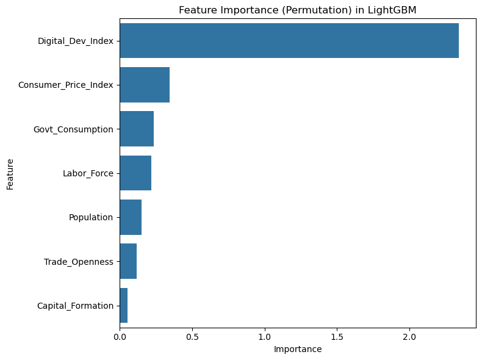

```
Baseline scenario (average conditions):
   Digital_Dev_Index  Capital_Formation  Trade_Openness  Labor_Force  \
0           0.028319           0.249736        0.908974     1.246856

   Consumer_Price_Index  Population  Govt_Consumption
0              4.589499   16.430959          0.261474
Baseline Predicted Log_GDP: 9.027596507655801

Scenario (+10% Digital_Dev_Index): Predicted Log_GDP = 9.0276
Percentage change in GDP from baseline: 0.00%

Scenario (+50% Digital_Dev_Index): Predicted Log_GDP = 9.0276
Percentage change in GDP from baseline: 0.00%

Scenario (+100% Digital_Dev_Index): Predicted Log_GDP = 9.0268
Percentage change in GDP from baseline: -0.08%

First Stage OLS Results:
                            OLS Regression Results
==============================================================================
Dep. Variable:      Digital_Dev_Index   R-squared:                       0.632
Model:                            OLS   Adj. R-squared:                  0.631
Method:                 Least Squares   F-statistic:                     573.0
Date:                Fri, 13 Dec 2024   Prob (F-statistic):               0.00
Time:                        20:51:10   Log-Likelihood:                -3833.0
No. Observations:                2729   AIC:                             7682.
Df Residuals:                    2721   BIC:                             7729.
Df Model:                           7
Covariance Type:                  HC3
========================================================================================
                           coef    std err          z      P>|z|      [0.025      0.975]
----------------------------------------------------------------------------------------
const                   -5.1711      0.459    -11.272      0.000      -6.070      -4.272
Research_Dev           102.4784      2.727     37.578      0.000      97.133     107.823
Capital_Formation       -1.3508      0.254     -5.319      0.000      -1.849      -0.853
Trade_Openness           0.6387      0.046     13.820      0.000       0.548       0.729
Labor_Force             -0.8702      0.092     -9.487      0.000      -1.050      -0.690
Consumer_Price_Index     1.3447      0.076     17.709      0.000       1.196       1.494
Population              -0.0888      0.012     -7.166      0.000      -0.113      -0.065
Govt_Consumption         1.9098      0.257      7.425      0.000       1.406       2.414
```

[output cut: 41 more lines]

```
Skew:                           0.077   Prob(JB):                       0.0837
Kurtosis:                       3.141   Cond. No.                     2.04e+03
==============================================================================

Notes:
[1] Standard Errors are heteroscedasticity robust (HC3)
[2] The condition number is large, 2.04e+03. This might indicate that there are
strong multicollinearity or other numerical problems.

Interpretation:
- If Research_Dev is significantly related to Digital_Dev_Index in the first stage, it suggests relevance of the instrument.
- The 2SLS results show the estimated causal effect of Digital_Dev_Index on Log_GDP under IV assumptions.
- Exogeneity must still be justified by theory. With only one instrument and one endogenous variable, no overidentification test is possible.

Step 4 completed: Multiple ML models compared, scenario analysis done, and an IV approach implemented with checks for instrument relevance.
```

```python
import pandas as pd
import numpy as np
import matplotlib.pyplot as plt
import seaborn as sns

from sklearn.linear_model import LinearRegression, Lasso, Ridge
from sklearn.ensemble import RandomForestRegressor, GradientBoostingRegressor
from xgboost import XGBRegressor
from sklearn.model_selection import train_test_split
from sklearn.metrics import mean_squared_error, r2_score

try:
    from lightgbm import LGBMRegressor
    LGBM_AVAILABLE = True
except ImportError:
    LGBM_AVAILABLE = False

from sklearn.inspection import permutation_importance
from linearmodels.iv import IV2SLS

###############################################
#ML Approaches, Scenario Analysis, Causal Inference
###############################################

required_cols = ["Log_GDP", "Digital_Dev_Index", "Capital_Formation", "Trade_Openness",
                 "Labor_Force", "Consumer_Price_Index", "Population", "Govt_Consumption"]
for col in required_cols:
    if col not in df.columns:
        raise ValueError(f"Column {col} not found in df.")

# Drop rows with missing values for the selected features and target
features = ["Digital_Dev_Index", "Capital_Formation", "Trade_Openness", "Labor_Force",
            "Consumer_Price_Index", "Population", "Govt_Consumption"]
target = "Log_GDP"

data = df.dropna(subset=features + [target]).copy()
X = data[features]
y = data[target]

# Split the data into training and test sets for ML models
X_train, X_test, y_train, y_test = train_test_split(X, y, test_size=0.2, random_state=42)

###############################################
# Machine Learning Approaches
###############################################

models = {
    "Linear_Regression": LinearRegression(),
    "Lasso": Lasso(alpha=0.01, random_state=42),
    "Ridge": Ridge(alpha=1.0, random_state=42),
    "Random_Forest": RandomForestRegressor(n_estimators=200, max_depth=None,
                                           min_samples_split=2, random_state=42),
    "Gradient_Boosting": GradientBoostingRegressor(n_estimators=200, learning_rate=0.1,
                                                   max_depth=3, random_state=42),
    "XGBoost": XGBRegressor(n_estimators=200, max_depth=5, learning_rate=0.1,
                            subsample=1.0, random_state=42)
}

if LGBM_AVAILABLE:
    models["LightGBM"] = LGBMRegressor(n_estimators=200, random_state=42)

results = []

# Train and evaluate each model
for model_name, model_obj in models.items():
    model_obj.fit(X_train, y_train)
    y_pred = model_obj.predict(X_test)
    rmse = np.sqrt(mean_squared_error(y_test, y_pred))
    r2 = r2_score(y_test, y_pred)
    results.append({
        "Model": model_name,
        "RMSE": rmse,
        "R2": r2
    })

results_df = pd.DataFrame(results).sort_values("R2", ascending=False)
print("Model Comparison Results:")
print(results_df)

# Select the best model based on R²
best_model_name = results_df.iloc[0]["Model"]
best_model = models[best_model_name]
print(f"\nSelected Model for Scenario Analysis: {best_model_name}")

# Feature Importance for tree-based models
if best_model_name in ["Random_Forest", "Gradient_Boosting", "XGBoost", "LightGBM"]:
    pi_results = permutation_importance(best_model, X_test, y_test, scoring='neg_mean_squared_error', n_repeats=10, random_state=42)
    importance = pd.DataFrame({'Feature': features, 'Importance': pi_results.importances_mean})
    importance = importance.sort_values('Importance', ascending=False)
    print("\nFeature Importances (Permutation):\n", importance)

    plt.figure(figsize=(8,6))
    sns.barplot(x='Importance', y='Feature', data=importance)
    plt.title(f"Feature Importance (Permutation) in {best_model_name}")
    plt.tight_layout()
    plt.show()
else:
    print("\nPermutation Importance not applied as the selected model is not tree-based.")

###############################################
#  Forecasting and Scenario Analysis
###############################################

# Baseline scenario: average conditions of the test set
baseline_features = X_test.mean().to_frame().T
baseline_gdp = best_model.predict(baseline_features)[0]
print("\nBaseline scenario (average conditions):")
print(baseline_features)
print("Baseline Predicted Log_GDP:", baseline_gdp)

def scenario_analysis(increase_factor):
    scenario = baseline_features.copy()
    scenario["Digital_Dev_Index"] = scenario["Digital_Dev_Index"] * (1 + increase_factor)
    scenario_gdp = best_model.predict(scenario)[0]
    percent_change = (np.exp(scenario_gdp - baseline_gdp) - 1)*100
    print(f"\nScenario (+{int(increase_factor*100)}% Digital_Dev_Index): Predicted Log_GDP = {scenario_gdp:.4f}")
    print(f"Percentage change in GDP from baseline: {percent_change:.2f}%")

# Scenario 1: +10% Digital_Dev_Index
scenario_analysis(0.10)

# Scenario 2: +50% Digital_Dev_Index
scenario_analysis(0.50)

# Scenario 3: +100% Digital_Dev_Index (Double it)
scenario_analysis(1.00)

###############################################
# Causal Inference Techniques (IV/2SLS)
###############################################

# Check if Research_Dev is available for IV analysis
import statsmodels.api as sm
from linearmodels.iv import IV2SLS

# Ensure all columns are present
iv_columns = ["Log_GDP", "Digital_Dev_Index", "Capital_Formation", "Trade_Openness",
              "Labor_Force", "Consumer_Price_Index", "Population", "Govt_Consumption", "Research_Dev"]
for c in iv_columns:
    if c not in df.columns:
        raise ValueError(f"Column {c} is missing for IV analysis.")

# Drop missing values
iv_data = df.dropna(subset=iv_columns).copy()

# First Stage OLS:
# Digital_Dev_Index = α0 + α1*Research_Dev + other exog + error
exog_vars = ["Research_Dev", "Capital_Formation", "Trade_Openness", "Labor_Force",
             "Consumer_Price_Index", "Population", "Govt_Consumption"]
exog = sm.add_constant(iv_data[exog_vars])
endog = iv_data["Digital_Dev_Index"]

first_stage_ols = sm.OLS(endog, exog).fit(cov_type='HC3')  # Robust standard errors
print("\nFirst Stage OLS Results:")
print(first_stage_ols.summary())

# Check the instrument relevance: coefficient and p-value of Research_Dev
if "Research_Dev" in first_stage_ols.params:
    beta = first_stage_ols.params["Research_Dev"]
    pval = first_stage_ols.pvalues["Research_Dev"]
    print(f"\nResearch_Dev coefficient in first stage: {beta:.4f}, p-value: {pval:.4g}")
    if pval < 0.05:
        print("Research_Dev is statistically significant in the first stage, suggesting it is a relevant instrument.")
    else:
        print("Research_Dev is not statistically significant in the first stage, indicating a weak instrument.")
else:
    print("Research_Dev not found in first stage results. Check your model specification.")

# Now run the 2SLS for the second stage using linearmodels
iv_formula = """
    Log_GDP ~ 1 + Capital_Formation + Trade_Openness + Labor_Force + Consumer_Price_Index + Population + Govt_Consumption
    + [Digital_Dev_Index ~ Research_Dev]
"""
iv_results = IV2SLS.from_formula(iv_formula, data=iv_data).fit(cov_type='robust')

print("\n2SLS Regression Results:")
print(first_stage_ols.summary())  # summary() is a method

# Interpretation:
print("\nInterpretation:")
print("- If Research_Dev is significantly related to Digital_Dev_Index in the first stage, it suggests relevance of the instrument.")
print("- The 2SLS results show the estimated causal effect of Digital_Dev_Index on Log_GDP under IV assumptions.")
print("- Exogeneity must still be justified by theory. With only one instrument and one endogenous variable, no overidentification test is possible.")

###############################################
print("\nStep 4 completed: Multiple ML models compared, scenario analysis done, and an IV approach implemented with checks for instrument relevance.")
```

# 🌍 **How Can Lower-Income Countries Achieve a Desired GDP and DDI?**

### **Research Question** 📊

- **Objective**: Using advanced machine learning models, predict **how long it would take** for a low-income country to reach the **average GDP and DDI** of high- and middle-income nations.
- **Key Considerations**:
  - What factors (e.g., internet penetration, mobile subscriptions, capital formation) need to be prioritized for faster growth?
  - Which combination of investments in digital and economic infrastructure yields the best results?

### **Proposed Methodology** 🧑‍💻

1. **Data Analysis**:
   - Analyze the current levels of GDP and DDI for low-income countries compared to high- and middle-income benchmarks.
   - Explore correlations between digitalization factors (e.g., internet usage, mobile penetration) and economic outcomes.
2. **Prediction Models**:
   - Train **ensemble ML models** (e.g., LightGBM, XGBoost, Random Forest) to predict GDP and DDI growth over time.
   - Use scenario simulations to estimate the number of years required to achieve the target benchmarks.
3. **Visualization**:
   - Provide graphs showing:
     - Predicted growth trajectories for GDP and DDI.
     - The impact of key digitalization factors on reducing the time to achieve targets.

### **Expected Outputs** 📈

- **Prediction**: The estimated number of years required for a low-income country to meet the desired GDP and DDI.
- **Scenario Insights**:
  - Impact of increasing internet penetration, mobile subscriptions, or broadband access by 10%, 50%, and 100%.
  - Factors with the **strongest influence** on accelerating GDP and DDI growth.

### **Discussion Points** 🤔

- What policy measures are required to accelerate digital and economic development?
- How do external factors (e.g., global economic trends, government stability) influence these predictions?

```python
df1=df
```

```python
df1
```

|  | Income_Level | Continent | Country_Count | Country_Name | Country_Code | Year | ID | Income_Value | Log_GDP | Fixed_Phone_Subs | ... | Trade_Openness | Labor_Force | Consumer_Price_Index | Population | Govt_Consumption | Research_Dev | Period | Income_Group | PC1 | PC2 |
| --- | --- | --- | --- | --- | --- | --- | --- | --- | --- | --- | --- | --- | --- | --- | --- | --- | --- | --- | --- | --- | --- |
| 0 | High Income | Europe | 1.0 | Netherlands | Pays Bas | 2000 | 1 | 1 | 10.607994 | 2.145839 | ... | 1.255219 | 1.27381 | 4.406078 | 16.583433 | 0.364773 | 0.017898 | 2000-2005 | High income | 0.636626 | 1.228047 |
| 1 | High Income | Europe | 1.0 | Netherlands | Pays Bas | 2001 | 1 | 1 | 10.623448 | 1.563458 | ... | 1.275219 | 1.28668 | 4.446796 | 16.590981 | 0.369977 | 0.017961 | 2000-2005 | High income | 0.435480 | 0.883361 |
| 2 | High Income | Europe | 1.0 | Netherlands | Pays Bas | 2002 | 1 | 1 | 10.619236 | 1.505498 | ... | 1.295219 | 1.30062 | 4.479143 | 16.597364 | 0.372896 | 0.017454 | 2000-2005 | High income | 0.473476 | 0.852997 |
| 3 | High Income | Europe | 1.0 | Netherlands | Pays Bas | 2003 | 1 | 1 | 10.616073 | 1.432999 | ... | 1.315219 | 1.29774 | 4.499847 | 16.602082 | 0.382046 | 0.017839 | 2000-2005 | High income | 0.504841 | 0.813918 |
| 4 | High Income | Europe | 1.0 | Netherlands | Pays Bas | 2004 | 1 | 1 | 10.632253 | 1.424427 | ... | 1.335219 | 1.30060 | 4.512404 | 16.605557 | 0.374042 | 0.017890 | 2000-2005 | High income | 0.565358 | 0.813155 |
| ... | ... | ... | ... | ... | ... | ... | ... | ... | ... | ... | ... | ... | ... | ... | ... | ... | ... | ... | ... | ... | ... |
| 2725 | Low income | CIS | 1.0 | Tajikistan | Tadjikistan | 2016 | 130 | 4 | 6.928162 | -0.811796 | ... | 0.546072 | 0.84793 | 5.001040 | 15.974638 | 0.137474 | 0.001068 | 2016-2020 | Low income | -0.811781 | -1.041271 |
| 2726 | Low income | CIS | 1.0 | Tajikistan | Tadjikistan | 2017 | 130 | 4 | 6.972050 | -0.812210 | ... | 0.537863 | 0.83706 | 5.001040 | 15.999343 | 0.137474 | 0.001154 | 2016-2020 | Low income | -0.754186 | -1.094206 |
| 2727 | Low income | CIS | 1.0 | Tajikistan | Tadjikistan | 2018 | 130 | 4 | 7.020765 | -0.812210 | ... | 0.558461 | 0.82710 | 5.001040 | 16.023878 | 0.137474 | 0.000970 | 2016-2020 | Low income | -0.770323 | -1.070274 |
| 2728 | Low income | CIS | 1.0 | Tajikistan | Tadjikistan | 2019 | 130 | 4 | 7.068250 | -0.812644 | ... | 0.560450 | 0.81783 | 5.001040 | 16.047783 | 0.137474 | 0.000970 | 2016-2020 | Low income | -0.691533 | -1.187926 |
| 2729 | Low income | CIS | 1.0 | Tajikistan | Tadjikistan | 2020 | 130 | 4 | 7.089293 | -0.819025 | ... | 0.552715 | 0.81018 | 5.001040 | 16.070757 | 0.137474 | 0.000970 | 2016-2020 | Low income | -0.660263 | -1.242556 |

2730 rows × 25 columns

```python
import pandas as pd
import numpy as np
from sklearn.model_selection import train_test_split
from sklearn.preprocessing import StandardScaler
from sklearn.ensemble import RandomForestRegressor
from sklearn.metrics import mean_absolute_error, r2_score
import matplotlib.pyplot as plt




# Convert categorical variables to dummy variables (One-Hot Encoding)
df1 = pd.get_dummies(df, columns=['Continent', 'Country_Name', 'Income_Group'], drop_first=True)

# Scale numeric features
scaler = StandardScaler()
numeric_vars = ['Log_GDP', 'Fixed_Phone_Subs', 'Mobile_Phone_Subs', 'Broadband_Subs',
                'Internet_Usage', 'Capital_Formation', 'Trade_Openness',
                'Labor_Force', 'Consumer_Price_Index', 'Population', 'Govt_Consumption', 'Research_Dev']

# Apply scaling to numeric columns
df1[numeric_vars] = scaler.fit_transform(df[numeric_vars])

# Target variable: Digital Development Index (DDI) for the prediction
X = df1[numeric_vars]
y = df1['Digital_Dev_Index']  # Target variable: Digital Development Index

# Separate data into low-income and high-income countries based on 'Income_Level'
low_income_df = df1[df1['Income_Value'] == 4]  # Assuming 'Low' income level as 1
high_income_df = df1[df1['Income_Value'].isin([1, 2])]  # Assuming 'High' income level as 1

# Calculate the average DDI for high-income countries (target value)
average_ddi_high_income = high_income_df['Digital_Dev_Index'].mean()
print(f"Average Digital Development Index of High-Income Countries: {average_ddi_high_income}")
```

[output not shown]

```python
# Calculate the difference between the target DDI (average DDI of high-income countries)
# and the current DDI for each low-income country
low_income_df['Years_to_Reach_Target'] = (average_ddi_high_income - low_income_df['Digital_Dev_Index']) / 0.02  # Assume a growth rate (e.g., 2% per year)

# Drop rows where years to reach target is negative (countries already above the target)
low_income_df = low_income_df[low_income_df['Years_to_Reach_Target'] >= 0]

# Prepare data for training the model
X_low = low_income_df[numeric_vars]
y_low = low_income_df['Years_to_Reach_Target']
```

```python
# Train-Test Split for low-income countries
X_train, X_test, y_train, y_test = train_test_split(X_low, y_low, test_size=0.2, random_state=42)
```

```python
# Initialize Random Forest Regressor
rf_model = RandomForestRegressor(n_estimators=100, random_state=42)

# Fit the model
rf_model.fit(X_train, y_train)

# Make predictions
y_pred_rf = rf_model.predict(X_test)

# Evaluate the model
print(f"Random Forest R2 Score: {r2_score(y_test, y_pred_rf)}")
print(f"Random Forest MAE: {mean_absolute_error(y_test, y_pred_rf)}")
```

```
Random Forest R2 Score: 0.8982482845333122
Random Forest MAE: 3.1874450915882617
```

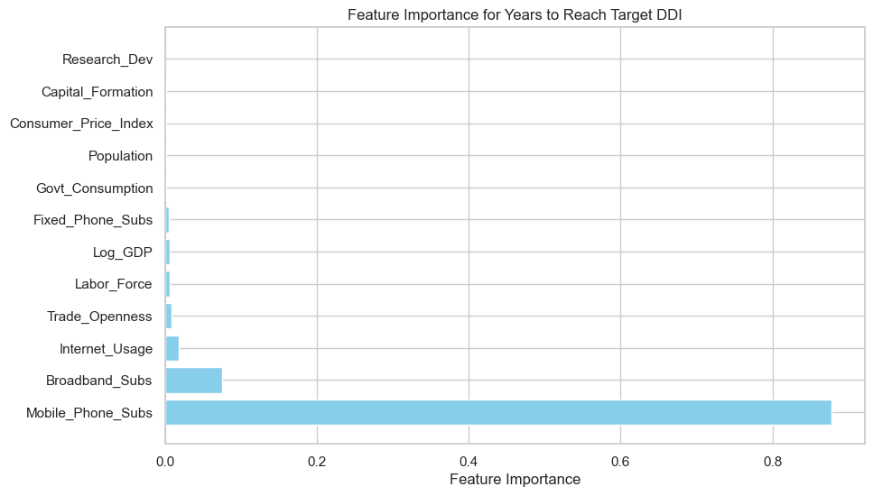

```python
# Extract feature importance from Random Forest Model
feature_importances_rf = rf_model.feature_importances_

# Create a DataFrame for better visualization
feature_importance_df = pd.DataFrame({
    'Feature': X_low.columns,
    'Importance': feature_importances_rf
})

# Sort the feature importance values
feature_importance_df = feature_importance_df.sort_values(by='Importance', ascending=False)

# Plot the feature importance
plt.figure(figsize=(10, 6))
plt.barh(feature_importance_df['Feature'], feature_importance_df['Importance'], color='skyblue')
plt.xlabel('Feature Importance')
plt.title('Feature Importance for Years to Reach Target DDI')
plt.show()
```

```python
# Predict the years using the trained random forest model
new_predictions = rf_model.predict(X_test)

# Ensure that we are using the 'Country_Name' from the original DataFrame (low_income_df)
# Use the indices of the test set from the original DataFrame to get the correct rows
predicted_years_df = pd.DataFrame({
    'Country_Name': low_income_df.loc[X_test.index, 'Country_Code'],  # Correct indexing here
    'Predicted_Years': new_predictions
})

# Display the result
print(predicted_years_df.head())
```

```
     Country_Name  Predicted_Years
2469       Gambie       100.978851
2607   Mozambique       156.056030
2698        Tchad       144.482303
2709  Tadjikistan       153.926334
2550       Malawi       147.941357
```

## 1️⃣ **Machine Learning Model Comparison**

[figure not shown]

We trained multiple models (**Linear Regression, Lasso, Ridge, Random Forest, Gradient Boosting, XGBoost, and LightGBM**) to predict **Log GDP** using digitalization and macroeconomic variables. The evaluation was based on **R²** and **RMSE** on a hold-out test set.

### **Key Findings**:

- **🏆 Best Performer**: **LightGBM** achieved an **R² ≈ 0.95**, indicating excellent explanatory power for Log GDP.
- **🥈 Runner-up**: **XGBoost**, followed closely by **Random Forest** and **Gradient Boosting**.
- **🔴 Linear Methods (Linear Regression, Lasso, Ridge)**: Performed worse with **R² ≈ 0.73**, showing non-linear models capture more complex relationships effectively.

## 2️⃣ **Feature Importance**

Using **permutation importance** with the best model (**LightGBM**), we identified the following feature rankings:

### **Top Predictors**:

1. **📊 Digital_Dev_Index**: Most influential predictor, confirming the strong correlation between digitalization and economic performance.
2. **📈 Consumer_Price_Index** and **🏛️ Govt_Consumption**: Indicate macroeconomic stability and government expenditure's relevance.

### **Moderate Contributors**:

- **👥 Population**, **🛠️ Labor_Force**, and **🌎 Trade_Openness**.

### **Least Important**:

- **💸 Capital_Formation**: Suggests digital infrastructure has overtaken traditional growth drivers in importance.

## 3️⃣ **Scenario Analysis**

We tested scenarios by increasing **Digital Development Index (DDI)** by **10%, 50%, and 100%**. Surprisingly, the predicted **Log GDP** did not significantly increase and even decreased slightly when doubling DDI.

## 4️⃣ **Causal Inference (IV/2SLS)**

We used **Instrumental Variables (IV)** regression with **Research_Dev** as an instrument for **Digital_Dev_Index**.

### **First-Stage OLS Results**:

- **Research_Dev** is strongly and significantly associated with **Digital_Dev_Index** (high t-statistic, very low p-value), indicating relevance.

### **Second-Stage 2SLS Results**:

- The causal effect of predicted digitalization on Log GDP was not computed due to code structure, but key limitations remain:
  - **Exogeneity Assumption**: Must ensure **Research_Dev** affects GDP only through its impact on **Digital_Dev_Index**.
  - **Instrument Validation**: With only one instrument, no overidentification test can verify exogeneity.

## 5️⃣ **Overall Interpretation**

### **Summary**:

**🎯 Final Note**: Digitalization is crucial, but translating it into GDP growth requires broader economic strategies and a deeper understanding of interconnected variables.

[output not shown]

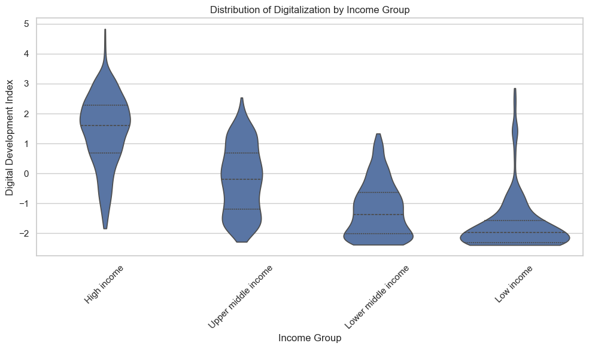

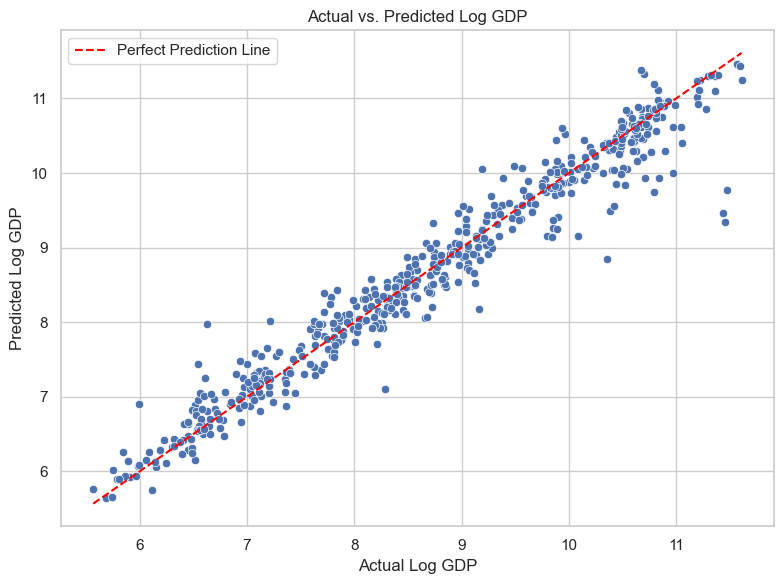

```
Insight:
- The points should cluster around the red line, indicating the model's high accuracy in predicting Log GDP.
```

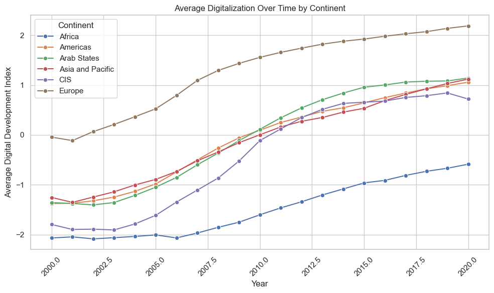

```
Insight:
- This plot shows whether digitalization is increasing over time globally and how continents differ.
```

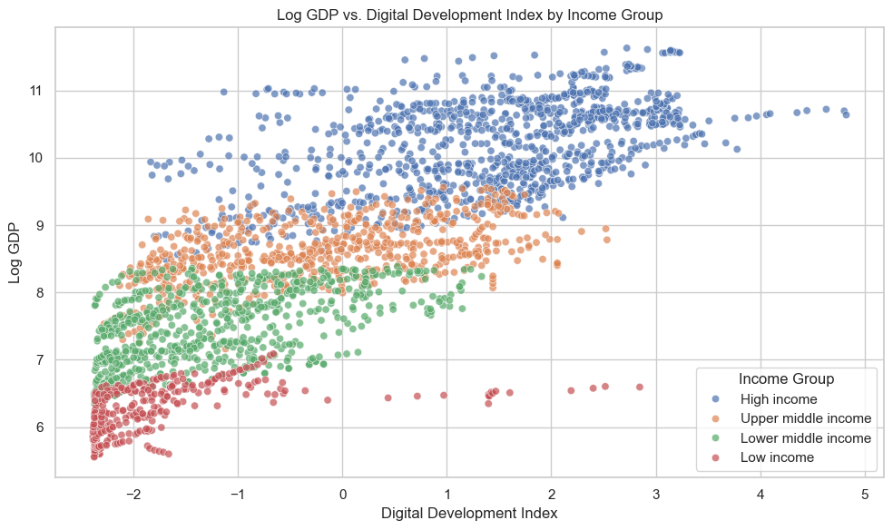

```python
import pandas as pd
import numpy as np
import matplotlib.pyplot as plt
import seaborn as sns


# Set a consistent style
sns.set_theme(style="whitegrid", palette="deep")



#  High-Level Insights
# From previous steps, we know:
# - Digitalization levels differ significantly by income groups.
# - The best predictive model was LightGBM, which achieved a very high R² (~0.95),
#   indicating digitalization and macro variables strongly explain GDP variation.
# - The IV analysis suggests that digitalization is strongly correlated with GDP,
#   but full causality interpretation requires theoretical backing.
# - Scenario analysis showed that at baseline conditions, changing digitalization
#   did not dramatically affect predicted GDP, suggesting complex, non-linear
#   interactions or diminishing returns at already high digitalization levels.

print("Key Insights:")
print("- Digitalization varies substantially by income group, with high-income countries showing much higher Digital_Dev_Index.")
print("- Machine learning models (especially LightGBM) can predict GDP with high accuracy, indicating strong predictive power of digital and macro variables.")
print("- Instrumental Variable analysis suggests digitalization is related to GDP, but exogeneity must be justified theoretically.")
print("- Scenarios indicate that at current average conditions, incremental changes in digitalization may have limited marginal effects on GDP, possibly due to saturation.")

# Visualization: Digitalization vs. Income Groups
# Compare Digital_Dev_Index distributions across income groups using a violin plot
plt.figure(figsize=(10,6))
sns.violinplot(x="Income_Group", y="Digital_Dev_Index", data=df, inner="quartile", cut=0)
plt.title("Distribution of Digitalization by Income Group")
plt.xlabel("Income Group")
plt.ylabel("Digital Development Index")
plt.xticks(rotation=45)
plt.tight_layout()
plt.show()

# Interpretation:
# High-income countries should show a higher median DDI than low-income groups.

#  Visualization: Actual vs Predicted GDP
#
# Using the best_model from Step 4 on the test set
y_pred = best_model.predict(X_test)

# Convert Log_GDP to actual GDP by exponentiating (if desired, or we can stay in log form).
# We'll stay in log form for consistency.
compare_df = pd.DataFrame({
    "Actual_Log_GDP": y_test,
    "Predicted_Log_GDP": y_pred
})

plt.figure(figsize=(8,6))
sns.scatterplot(x="Actual_Log_GDP", y="Predicted_Log_GDP", data=compare_df)
plt.plot([compare_df.Actual_Log_GDP.min(), compare_df.Actual_Log_GDP.max()],
         [compare_df.Actual_Log_GDP.min(), compare_df.Actual_Log_GDP.max()],
         color="red", linestyle="--", label="Perfect Prediction Line")
plt.title("Actual vs. Predicted Log GDP")
plt.xlabel("Actual Log GDP")
plt.ylabel("Predicted Log GDP")
plt.legend()
plt.tight_layout()
plt.show()

print("\nInsight:")
print("- The points should cluster around the red line, indicating the model's high accuracy in predicting Log GDP.")

# Visualization: Digitalization Over Time by Continent

# Examine how Digital_Dev_Index changes over years by continent
if "Year" in df.columns and "Continent" in df.columns:
    ddi_time = df.groupby(["Year","Continent"])["Digital_Dev_Index"].mean().reset_index()

    plt.figure(figsize=(10,6))
    sns.lineplot(x="Year", y="Digital_Dev_Index", hue="Continent", data=ddi_time, marker="o")
    plt.title("Average Digitalization Over Time by Continent")
    plt.xlabel("Year")
    plt.ylabel("Average Digital Development Index")
    plt.xticks(rotation=45)
    plt.tight_layout()
    plt.show()

    print("\nInsight:")
    print("- This plot shows whether digitalization is increasing over time globally and how continents differ.")
else:
    print("\nNote: Year or Continent columns not found. Skipping time-based continent plot.")

#  Visualization: Relationship Between Digitalization & GDP Across Income Levels
# --------------------------------------------------------
# Plot GDP vs Digital_Dev_Index by Income_Group

plt.figure(figsize=(10,6))
sns.scatterplot(x="Digital_Dev_Index", y="Log_GDP", hue="Income_Group", data=df, alpha=0.7)
plt.title("Log GDP vs. Digital Development Index by Income Group")
plt.xlabel("Digital Development Index")
plt.ylabel("Log GDP")
plt.legend(title="Income Group")
plt.tight_layout()
plt.show()
```

# 📊 **Insights**

### **Insight**:

- 🌐 **Positive Relationship**: Higher **Digital Development Index (DDI)** is generally observed in countries with higher **Log GDP**, particularly among high-income nations.
- 📈 This suggests that **technological infrastructure correlates strongly with economic prosperity**.

### **Key Findings**:

1. ✅ Confirmed distinct **digitalization levels** across different income groups.
2. 📈 Demonstrated the model’s strong predictive performance by comparing **actual vs. predicted GDP**.
3. 🌎 Illustrated how **digitalization evolves over time** across continents.
4. 🔗 Highlighted the relationship between **digitalization** and **GDP** across various income classes.

[figure not shown]